# Data Camp Insights

Combining scales:

- Can use dotplot(y ~ x | c + d, data=, as.table=TRUE) to have a conditioned dot-plot on c and d
  - Expects a categorical variable on at least one of the axes (typically, but not always, y)
- The default for axis limits is for them to be common across all the panels - typically, best for interpretation
  - Can override the default behavior using the scales argument, a list with named components
  - relation = “same” is the default
  - relation = “free” allows independence for each panel
  - relation = “sliced” allows different limits for each panel, but with same range (???)
- The call to scales is fairly complicated
  - scales = list(x = list(relation = “free”)) # asks for an x-axis scale to be free
- Some other useful sub-components of the scales argument are:
  - tick.number: approximate number of tick marks / labels
  - alternating: 1 puts labels on the left/bottom boundary, 2 on the right/top, and 3 on both sides. The value can be a vector, in which case it applies row-wise or column-wise
  - rot: angle in degrees to rotate axis labels

Logarithmic scales:

- Can use dotplot(y ~ x | c, data=, groups=d, as.table=TRUE) will use d as a grouping variable with the plots only conditioned on c
- Can use the log() transform directly on the y variable to help with visualizing the data
- Alternately, can keep the data the same but just stretch the scales
  - dotplot(y ~ x | c, data=, groups=d, scales=list(x = list(log = 2, equispaced.log=FALSE)), auto.key=list(columns=2))
- There is one more component you need to know, equispaced.log
  - This component indicates if the tick marks are equispaced when log scales are in use
  - By default, equispaced.log is set to TRUE
  - Note: If you set equispaced.log = FALSE, you don’t have to explicitly specify a base for the log component; just log = TRUE should do the trick!

Graphical parameters:

- A collection of graphical parameters is referred to as a theme, frequently stored globally so it can be easily re-used
- The trellis.par.set(myTheme) will work to set myTheme as the theme for the upcoming plot
  - The latticeExtra package has ggplot2like() which will help match up the ggplot2 defaults
- Can also control graphical parameters by way of calls within a graphin function
  - For example, pch=15, col=c(“red”, “blue”)
- Changing the graphical theme using trellis.par.set(), as demonstrated in the preceding video, makes the changes permanent, applying to all subsequent plots, until the theme is reset
  - If you wish to make changes for a specific plot, an easier alternative is to supply the theme as the optional argument par.settings to a high-level call
  - In that case, the settings will be associated only to that particular call
  - In this exercise, you will use this approach to create a dot plot of the WorldPhones data with the ggplot2like() theme
  - As we saw earlier, changing the theme alone may be insufficient; we also need to change other things like the spacing between panels
  - Such settings (which are not considered graphical parameters) can also be customized through a list of “options”
  - To go with the ggplot2like() theme, the latticeExtra package also provides a suitable list of options, produced by ggplot2like.opts()
- Options can be associated to a particular plot by specifying it as the lattice.options argument in a high-level call, or set more permanently using the lattice.options() function

Using simpleTheme():

- Empty circles are the default plotting symbol
  - The pch=16 will create filled-in circles
- Interesting, changing parameters like pch in the function call apply only to the data, not to the legend describing the data
  - Can instead make changes that apply to everything by specifying (inside the function) par.settings = simpleTheme(pch=16, col=c(“red”, “blue”))
  - The simpleTheme() call will only change the requested options, leaving the global theme for everything else

Example code includes:

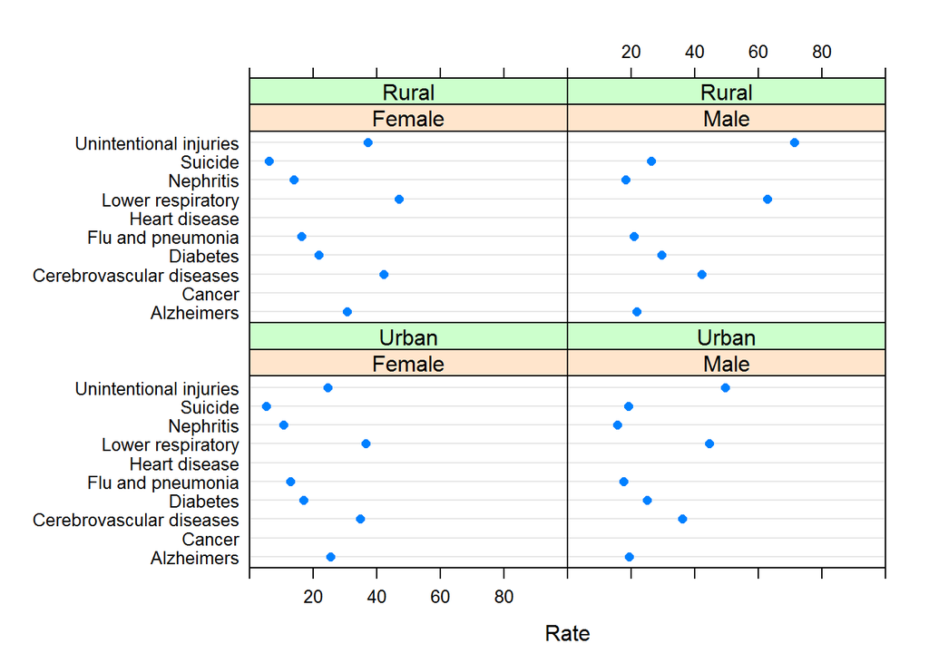

```r
# The lattice package and the USMortality dataset have been pre-loaded.
Status <- factor(c('Urban', 'Rural', 'Urban', 'Rural', 'Urban', 'Rural', 'Urban', 'Rural', 'Urban', 'Rural', 'Urban', 'Rural', 'Urban', 'Rural', 'Urban', 'Rural', 'Urban', 'Rural', 'Urban', 'Rural', 'Urban', 'Rural', 'Urban', 'Rural', 'Urban', 'Rural', 'Urban', 'Rural', 'Urban', 'Rural', 'Urban', 'Rural', 'Urban', 'Rural', 'Urban', 'Rural', 'Urban', 'Rural', 'Urban', 'Rural'), levels=c("Rural", "Urban")
                 )
Sex <- factor(c('Male', 'Male', 'Female', 'Female', 'Male', 'Male', 'Female', 'Female', 'Male', 'Male', 'Female', 'Female', 'Male', 'Male', 'Female', 'Female', 'Male', 'Male', 'Female', 'Female', 'Male', 'Male', 'Female', 'Female', 'Male', 'Male', 'Female', 'Female', 'Male', 'Male', 'Female', 'Female', 'Male', 'Male', 'Female', 'Female', 'Male', 'Male', 'Female', 'Female'), levels=c("Female", "Male")
              )
Cause <- factor(c('Heart disease', 'Heart disease', 'Heart disease', 'Heart disease', 'Cancer', 'Cancer', 'Cancer', 'Cancer', 'Lower respiratory', 'Lower respiratory', 'Lower respiratory', 'Lower respiratory', 'Unintentional injuries', 'Unintentional injuries', 'Unintentional injuries', 'Unintentional injuries', 'Cerebrovascular diseases', 'Cerebrovascular diseases', 'Cerebrovascular diseases', 'Cerebrovascular diseases', 'Alzheimers', 'Alzheimers', 'Alzheimers', 'Alzheimers', 'Diabetes', 'Diabetes', 'Diabetes', 'Diabetes', 'Flu and pneumonia', 'Flu and pneumonia', 'Flu and pneumonia', 'Flu and pneumonia', 'Suicide', 'Suicide', 'Suicide', 'Suicide', 'Nephritis', 'Nephritis', 'Nephritis', 'Nephritis'),
                levels=c('Alzheimers', 'Cancer', 'Cerebrovascular diseases', 'Diabetes', 'Flu and pneumonia', 'Heart disease', 'Lower respiratory', 'Nephritis', 'Suicide', 'Unintentional injuries')
                )
Rate <- c(210.2, 242.7, 132.5, 154.9, 195.9, 219.3, 140.2, 150.8, 44.5, 62.8, 36.5, 46.9, 49.6, 71.3, 24.7, 37.2, 36.1, 42.2, 34.9, 42.2, 19.4, 21.8, 25.5, 30.6, 24.9, 29.5, 17.1, 21.8, 17.7, 20.8, 12.9, 16.3, 19.2, 26.3, 5.3, 6.2, 15.7, 18.3, 10.7, 13.9)
SE <- c(0.2, 0.6, 0.2, 0.4, 0.2, 0.5, 0.2, 0.4, 0.1, 0.3, 0.1, 0.2, 0.1, 0.3, 0.1, 0.2, 0.1, 0.2, 0.1, 0.2, 0.1, 0.2, 0.1, 0.2, 0.1, 0.2, 0.1, 0.2, 0.1, 0.2, 0.1, 0.1, 0.1, 0.2, 0, 0.1, 0.1, 0.2, 0, 0.1)

USMortality <- data.frame(Status=Status, Sex=Sex, Cause=Cause, Rate=Rate, SE=SE)


# Specify upper bound to exclude Heart disease and Cancer
x_limits <- c(0, 100)

# Draw the plot
dotplot(Cause ~ Rate | Sex + Status, data = USMortality, as.table = TRUE,
        xlim = x_limits)
```

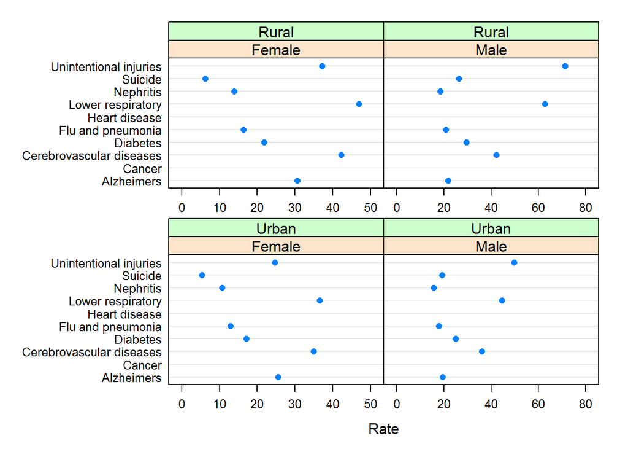

```r
dotplot(Cause ~ Rate | Sex + Status, data = USMortality,
        as.table = TRUE,
        scales = list(x = list(relation = "free",
                               # Specify limits for each panel
                               limits = list(c(0, 50), c(0, 80),
                                             c(0, 50), c(0, 80) ))))
```

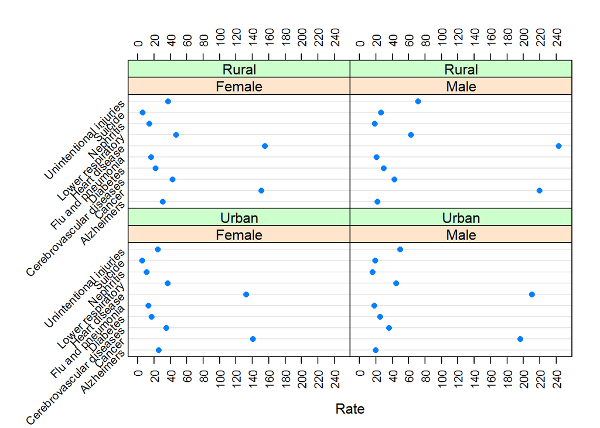

```r
dotplot(Cause ~ Rate | Sex + Status, data = USMortality,
        as.table = TRUE,
        # Change the number of tick marks
        scales = list(x = list(tick.number = 10,
                               # Show `Rate` labels on both bottom and top
                               alternating = 3,
                               # Rotate `Rate` labels by 90 degrees
                               rot = 90),
                      # Rotate `Cause` labels by 45 degrees
                      y = list(rot = 45)))
```

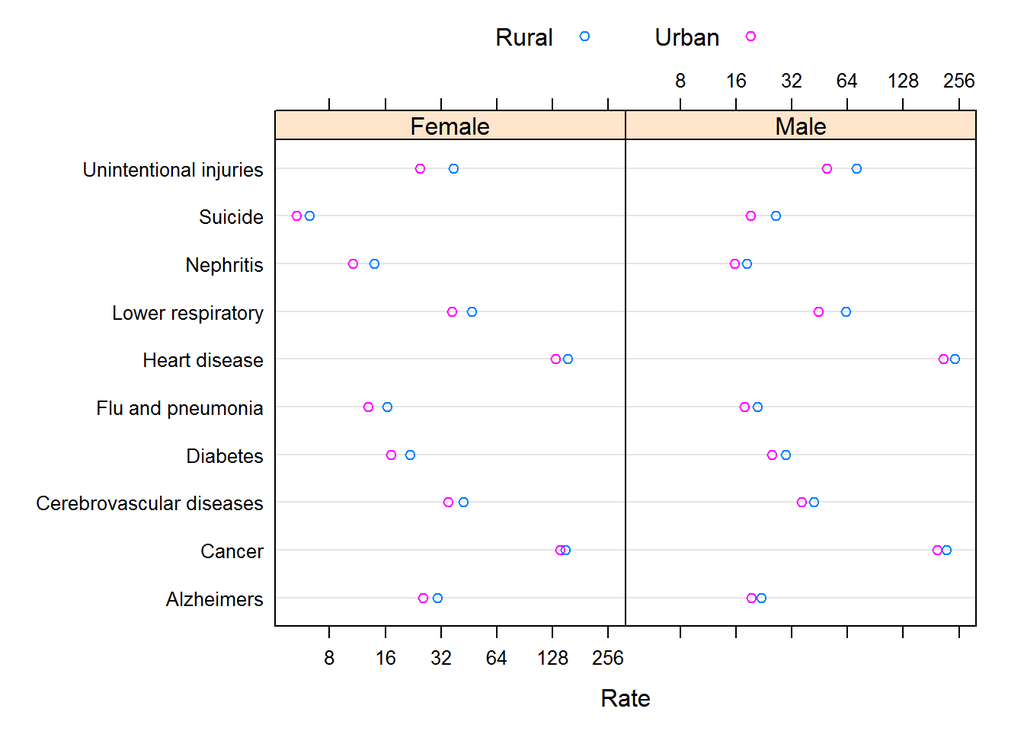

```r
# Define at as 2^3 up to 2^8
x_ticks_at <- 2 ** (3:8)

dotplot(Cause ~ Rate | Sex, data = USMortality,
        groups = Status, auto.key = list(columns = 2),
        scales = list(x = list(log = 2,
                               # A numeric vector with
                               # values 2^3, 2^4, ..., 2^8
                               at = x_ticks_at,
                               # A character vector,
                               # "8" for 2^3, "16" for 2^4, etc.
                               labels = x_ticks_at)))
```

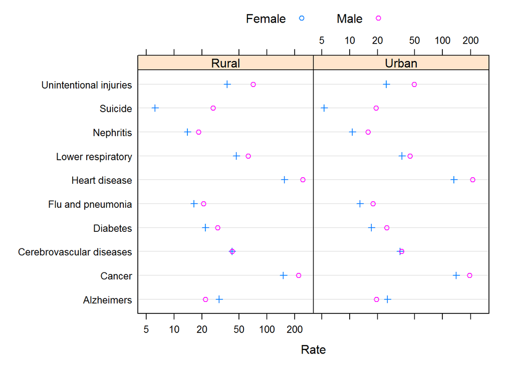

```r
# Create the dot plot
dotplot(Cause ~ Rate | Status, data = USMortality,
        groups = Sex, auto.key = list(columns = 2),
        scales = list(x = list(log = TRUE,
                      equispaced.log = FALSE)),
        # Provide pch values for the two groups
        pch = c(3, 1))
```

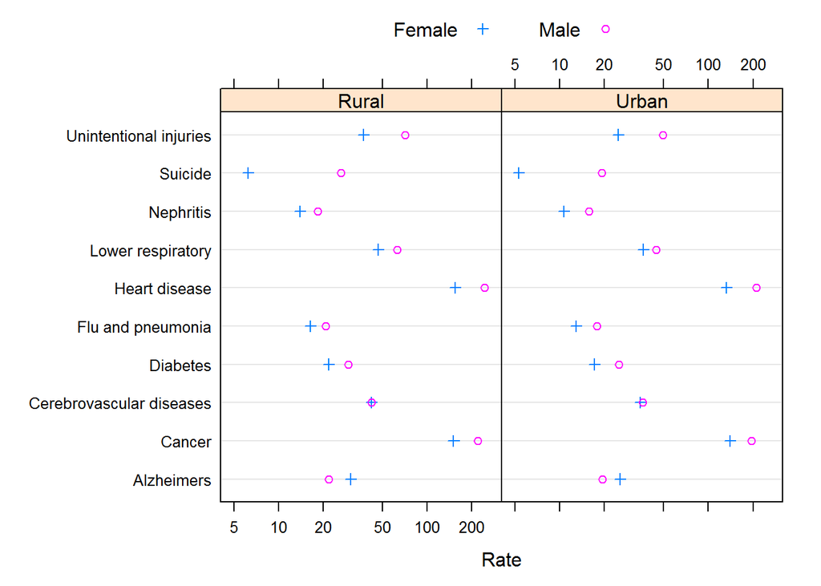

```r
dotplot(Cause ~ Rate | Status, data = USMortality,
        groups = Sex, auto.key = list(columns = 2),
        par.settings = simpleTheme(pch = c(3, 1)),
        scales = list(x = list(log = 2, equispaced.log = FALSE)))
```

```r
# The WorldPhones matrix is already provided, with the first row removed so you only need consider consecutive years
data(WorldPhones)
WorldPhones <- WorldPhones[row.names(WorldPhones) != 1951, ]
WorldPhones
```

```
##      N.Amer Europe Asia S.Amer Oceania Africa Mid.Amer
## 1956  60423  29990 4708   2568    2366   1411      733
## 1957  64721  32510 5230   2695    2526   1546      773
## 1958  68484  35218 6662   2845    2691   1663      836
## 1959  71799  37598 6856   3000    2868   1769      911
## 1960  76036  40341 8220   3145    3054   1905     1008
## 1961  79831  43173 9053   3338    3224   2005     1076
```

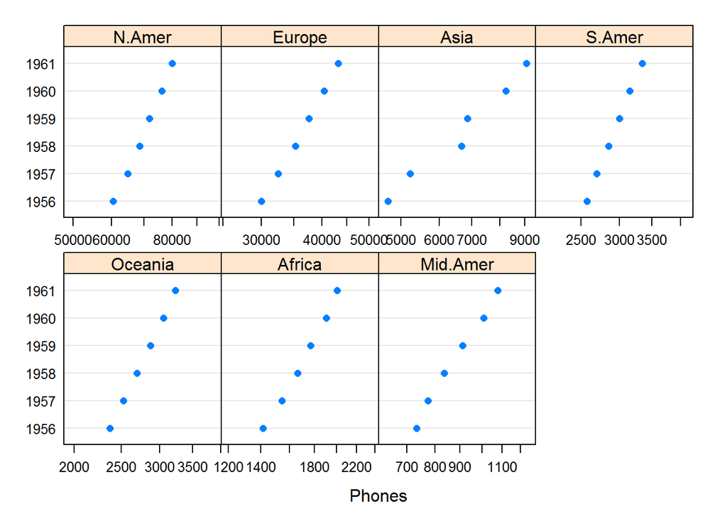

```r
names(dimnames(WorldPhones)) <- c("Year", "Region")

# Transform matrix data to data frame
WorldPhonesDF <- as.data.frame(
                   # Intermediate step: convert to table
                   as.table(WorldPhones),
                   responseName = "Phones")

# Create the dot plot
dotplot(Year ~ Phones | Region,
        data = WorldPhonesDF,
        as.table = TRUE,
        # Log-transform the x-axis
        scales = list(x = list(log = TRUE,
                               equispaced.log = FALSE,
                               # Set x-axis relation to "sliced"
                               relation = "sliced")))
```

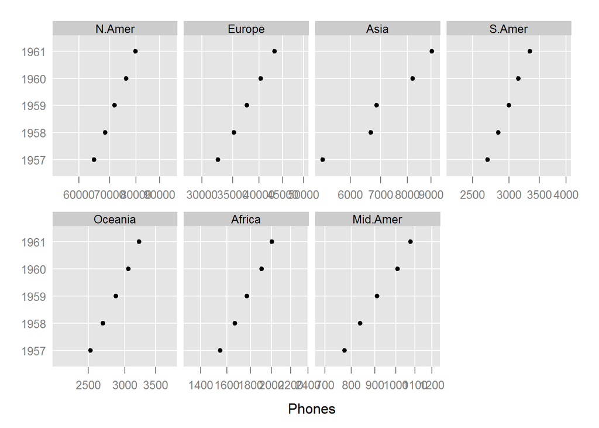

```r
# Load latticeExtra package for ggplot2like()
library(latticeExtra)
# Transform matrix data to data frame
names(dimnames(WorldPhones)) <- c("Year", "Region")
WorldPhonesDF <-
  as.data.frame(as.table(WorldPhones[-1, ]),
                responseName = "Phones")

# Create the dot plot
dotplot(Year ~ Phones | Region,
        data = WorldPhonesDF,
        as.table = TRUE,
        scales = list(x = list(log = TRUE,
                               equispaced.log = FALSE,
                               relation = "sliced")),
        # Fill in suitable value of par.settings
        par.settings = ggplot2like(),
        # Fill in suitable value of lattice.options
        lattice.options = ggplot2like.opts())
```

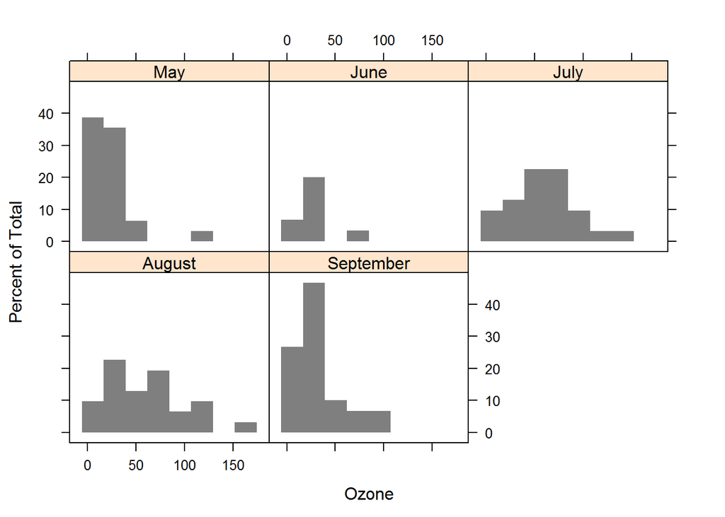

```r
# Create factor variable
airquality$Month.Name <-
  factor(airquality$Month, levels = 1:12,
         labels = month.name[1:12])

# Create histogram of Ozone, conditioning on Month
histogram(~ Ozone | Month.Name,
          data = airquality, as.table = TRUE,
          # Set border to be transparent
          border = "transparent",
          # Set fill color to be mid-gray
          col = "grey50")
```

```r
# Create factor variable
airquality$Month.Name <-
  factor(airquality$Month, levels = 1:12,
         labels = month.name)
levels(airquality$Month.Name)
```

```
##  [1] "January"   "February"  "March"     "April"     "May"
##  [6] "June"      "July"      "August"    "September" "October"
## [11] "November"  "December"
```

```r
# Drop empty levels
airquality$Month.Name <- droplevels(airquality$Month.Name)
levels(airquality$Month.Name)
```

```
## [1] "May"       "June"      "July"      "August"    "September"
```

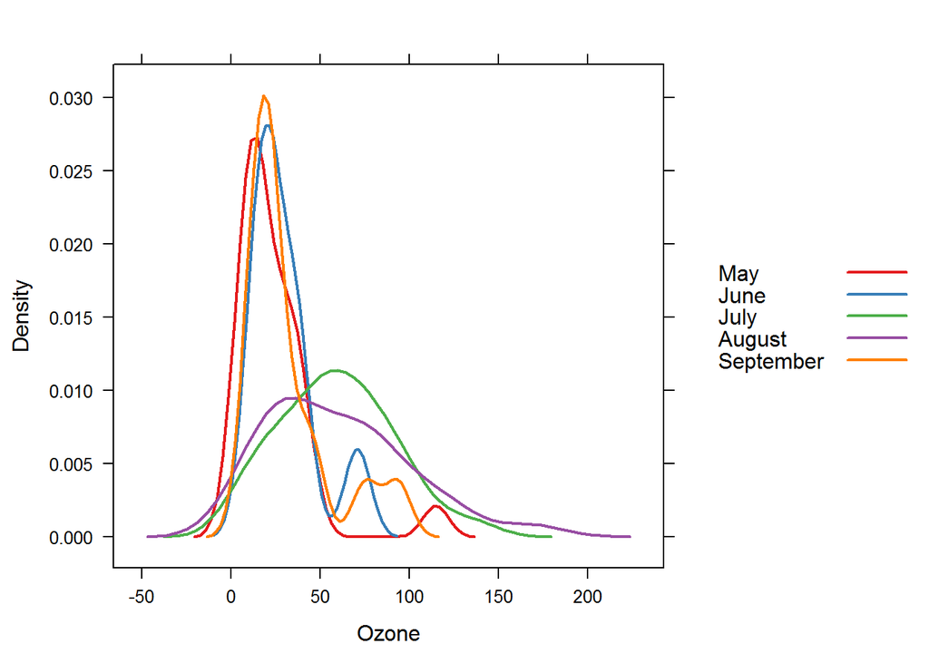

```r
# Obtain colors from RColorBrewer
library(RColorBrewer)
my.colors <- brewer.pal(n = 5, name = "Set1")

# Density plot of ozone concentration grouped by month
densityplot(~ Ozone, data = airquality, groups = Month.Name,
            plot.points = FALSE,
            auto.key = list(space = "right"),
            # Fill in value of col
            par.settings = simpleTheme(col = my.colors,
                                       # Fill in value of lwd
                                       lwd = 2))
```

Chapter 4 - Customizing plots using panel functions

Panel functions:

- Declarative approach (you provide specifications, system figures out requirements) is used by ggplot2
- Procedural approach (you provide step-by-step) is used by lattice and base R
- Custom displays in lattice cannot be created directly by faceting; instead, function build-up is needed
  - panel.histdens <- function(x, .) { panel.histogram(x, .) ; panel.lines(density(x, na.rm=TRUE)) } # overlay a density with a density histogram
  - The panel.histdens is then used inside the function, such as panel=panel.histdens inside a call to histogram()
  - The base R functions like lines and points need to be replaced by their lattice equivalents like panel.lines and panel.points for the lattice code to work
- Rather than customizing a default display, sometimes you may want to replace it entirely
  - An example of this is a violin plot, which is structured like a box and whisker plot, but instead of the boxes and whiskers, it uses kernel density estimates to summarize a distribution
  - The resulting plot retains the compactness of a box and whisker plot, but also shows features like bimodality
  - The built-in function panel.violin() in the lattice package implements the display of violin plots
- When there are a large number of points in the data, there may be substantial overplotting in a standard scatter plot
  - Another built-in panel function available in the lattice package that can serve as a replacement for panel.xyplot() in such cases is panel.smoothScatter()
  - Instead of plotting the points directly, it uses a color gradient to show a 2-D kernel density estimate obtained from the data
  - xyplot(rate.female ~ rate.male, data = USCancerRates, panel = panel.smoothScatter, scales = list(log = TRUE, equispaced.log = FALSE), main = “County-wise deaths due to cancer”)

Prepanel Functions to control limits:

- Controlling the x/y axis limits is enabled within lattice
  - prepanel.histdens.1 <- function(x, …) { d <- density(x, na.rm = TRUE); list(ylim = c(0, max(d$y))) }
  - histogram(~ rate.male + rate.female, USCancerRates, type = “density”, scales = list(x = list(log = 10)), xlab = “Rate”, panel = panel.histdens, prepanel = prepanel.histdens.1)

Optional arguments of default panel functions:

- Some optional arguments are common to all high-level functions in lattice - xlab, ylab, main, layout, between, scales
- Some optional arguments are specific to a single high-level function
  - nint, type - histogram()
  - plot.points, ref - densityplot()
  - grad, abline - xyplot()
  - col, cwd, cex, pch
- The high-level functions will handle the general arguments, while sweeping up all the others for passage to the panel functions
  - For example, passing grid=TRUE in xyplot() passes the argument to panel.xyplot()
- The type argument for xyplot adds a number of arguments
  - “p” - points
  - “l” - lines
  - “r” - regresion by way of panel.lmline()
  - “smooth” - LOESS smooth by way of panel.loess()
  - “a” - join average y values for each unique x value by way of panel.average()
  - Multiple types can be specified as a vector
- Note a few following features for an xyplot()
  - grid = list(h=-1, v=0) # draws horizontal reference lines
  - type = c(“p”, “a”) draws the points and a line connecting their averages
  - jitter.x = TRUE will apply a jitter on the x-axis only
- The default panel function for bwplot() has two additional arguments that you have not used before:
  - pch = “|” replaces the black dot representing the median inside the box by a line segment dividing the box into two smaller rectangles
  - notch = TRUE puts “notches” on the side of the boxes that indicate a confidence interval for median
  - the overlapping of notches for two subgroups suggests that the true medians of the two subgroups are not significantly different
- For the last exercise in this chapter, your task is to recreate a grouped dot plot you have seen before, but replace the plotting characters by emoji images
  - To do so, you will use the panel.xyimage() function in the latticeExtra package, which is similar to the panel.xyplot() function,
  - except that plotting symbols are replaced by images whose locations (file names or URLs of JPEG or PNG image files) are specified as the pch argument

Example code includes:

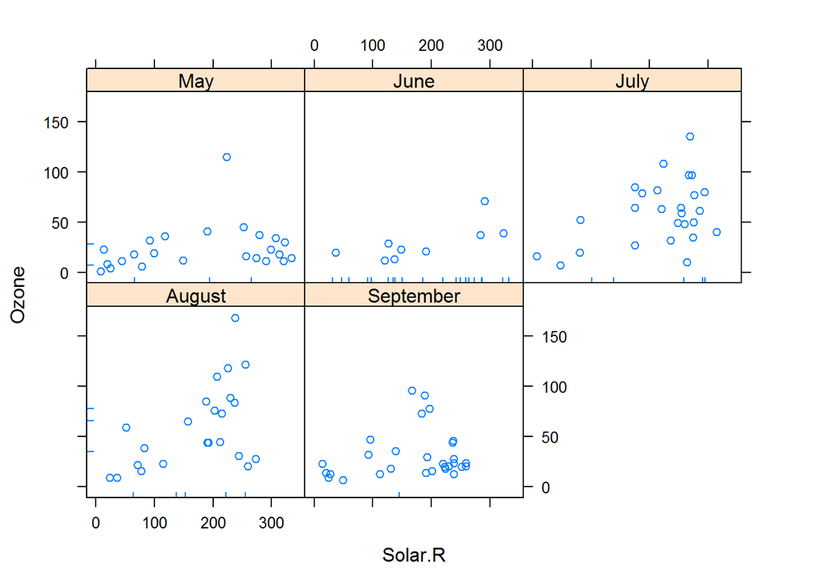

```r
panel.xyrug <- function(x, y, ...)
{
  # Reproduce standard scatter plot
  panel.xyplot(x, y, ...)

  # Identify observations with x-value missing
  x.missing <- is.na(x)

  # Identify observations with y-value missing
  y.missing <- is.na(y)

  # Draw rugs along axes
  panel.rug(x = x[y.missing], y = y[x.missing])
}

airquality$Month.Name <-
    factor(month.name[airquality$Month], levels = month.name)

xyplot(Ozone ~ Solar.R | Month.Name, data = airquality,
       panel = panel.xyrug, as.table = TRUE)
```

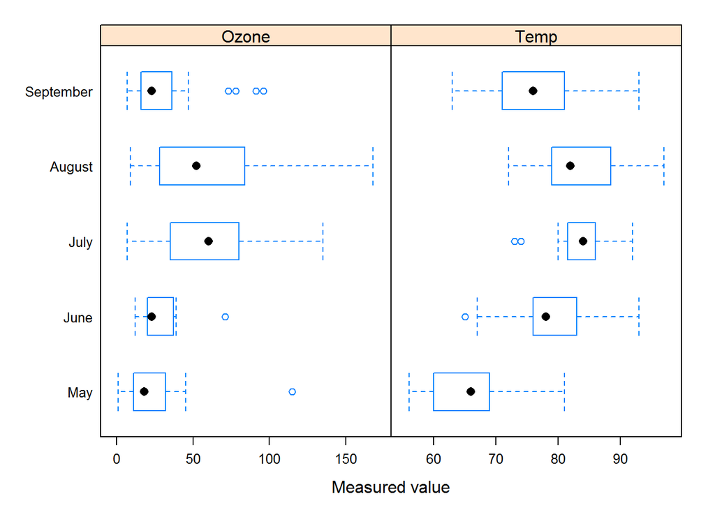

```r
# Create factor variable with month names
airquality$Month.Name <-
  factor(month.name[airquality$Month], levels = month.name)

# Create box-and-whisker plot
bwplot(Month.Name ~ Ozone + Temp, airquality,
       # Specify outer
       outer=TRUE,
       # Specify x-axis relation
       scales = list(x = list(relation="free")),
       # Specify layout
       layout=c(2, 1),
       # Specify x-axis label
       xlab="Measured value")
```

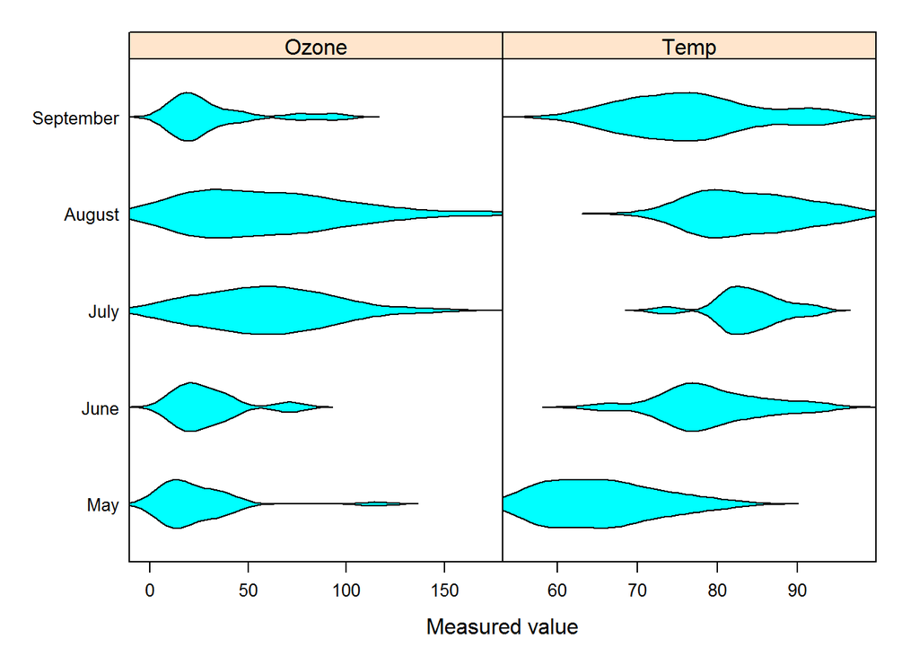

```r
# Create violin plot
bwplot(Month.Name ~ Ozone + Temp, airquality,
       # Specify outer
       outer = TRUE,
       # Specify x-axis relation
       scales = list(x = list(relation="free")),
       # Specify layout
       layout=c(2, 1),
       # Specify x-axis label
       xlab="Measured value",
       # Replace default panel function
       panel = panel.violin)
```

```
## (loaded the KernSmooth namespace)
```

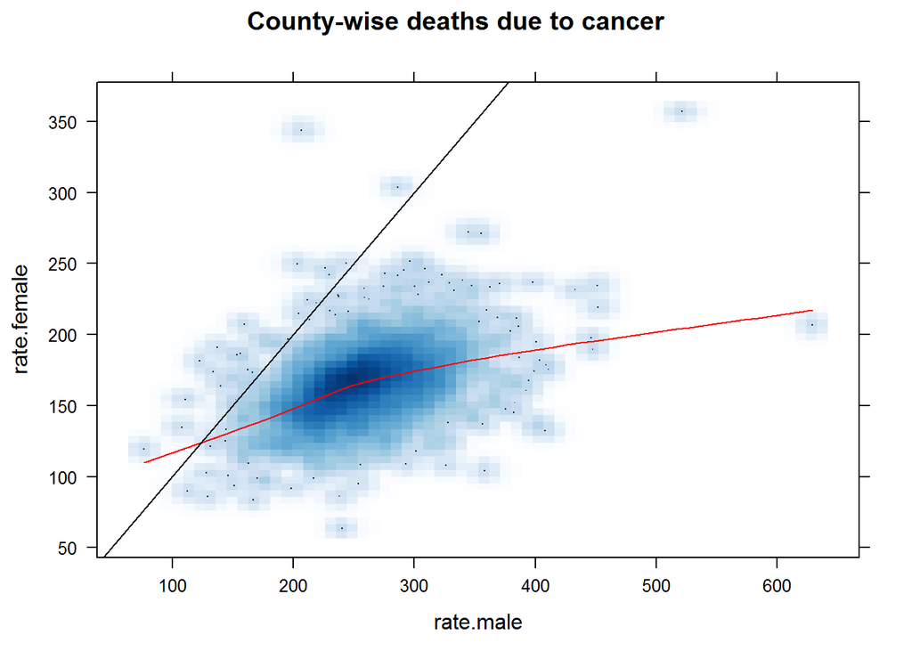

```r
# Create panel function
panel.ss <- function(x, y, ...) {
  # Call panel.smoothScatter()
  panel.smoothScatter(x, y, ...)
  # Call panel.loess()
  panel.loess(x, y, col = "red")
  # Call panel.abline()
  panel.abline(0, 1)
}

# Create plot
xyplot(rate.female ~ rate.male, data = USCancerRates,
       panel = panel.ss,
       main = "County-wise deaths due to cancer")
```

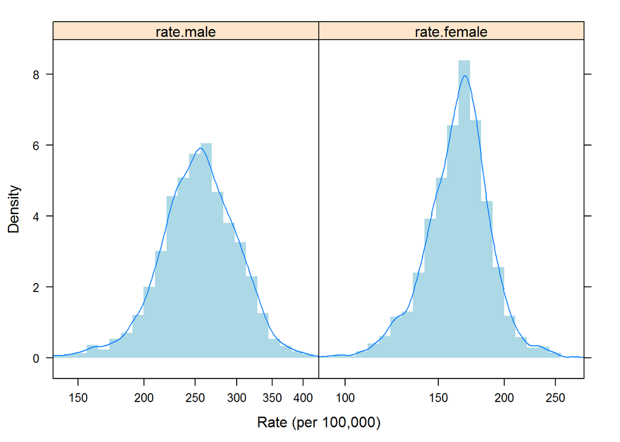

```r
# Define prepanel function
prepanel.histdens.2 <- function(x, ...) {
    h <- prepanel.default.histogram(x, ...)
    d <- density(x, na.rm = TRUE)
    list(xlim = quantile(x, c(0.005, 0.995), na.rm = TRUE),
         # Calculate upper y-limit
         ylim = c(0, max(d$y, h$ylim[2])))
}

panel.histdens <- function(x, ...) {
    panel.histogram(x, ...)
    panel.lines(density(x, na.rm = TRUE))
}

# Create a histogram of rate.male and rate.female
histogram(~ rate.male + rate.female,
          data = USCancerRates, outer = TRUE,
          type = "density", nint = 50,
          border = "transparent", col = "lightblue",
          # The panel function: panel.histdens
          panel = panel.histdens,
          # The prepanel function: prepanel.histdens.2
          prepanel = prepanel.histdens.2,
          # Ensure that the x-axis is log-transformed
          # and has relation "sliced"
          scales = list(x = list(log = TRUE,
                                 equispaced.log = FALSE,
                                 relation = "sliced")),
          xlab = "Rate (per 100,000)")
```

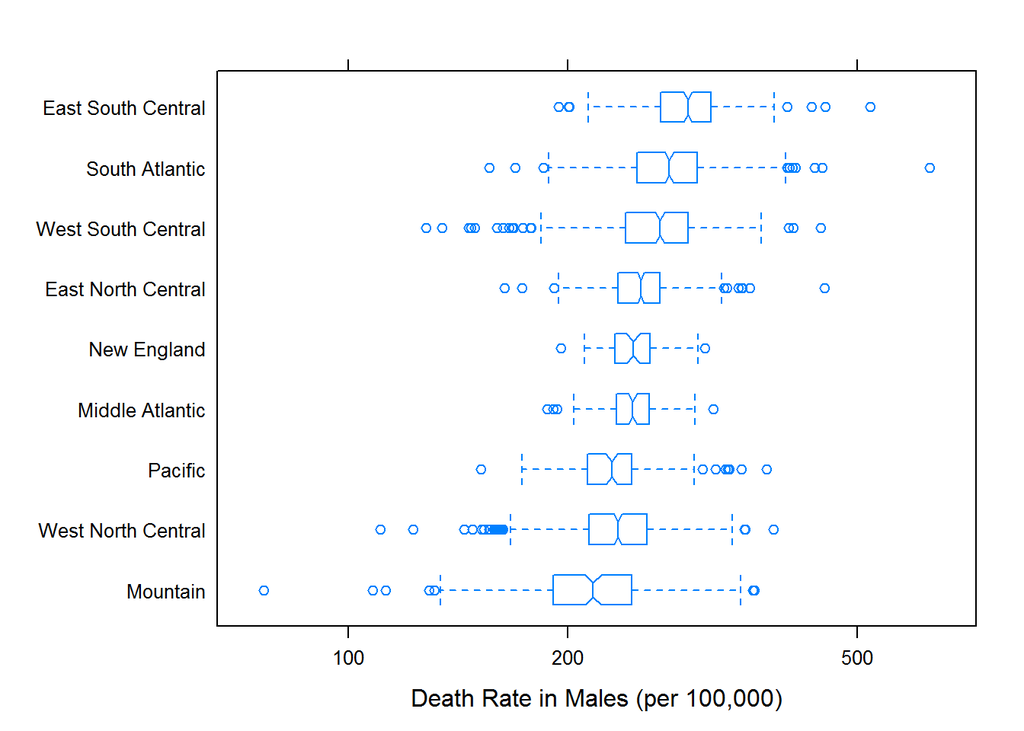

```r
# Create the box and whisker plot
bwplot(division.ordered ~ rate.male,
       data = USCancerRates,
       # Indicate median by line instead of dot
       pch = "|",
       # Include notches for confidence interval
       notch = TRUE,
       # The x-axis should plot log-transformed values
       scales = list(x = list(log=TRUE, equispaced.log=FALSE)),
       xlab = "Death Rate in Males (per 100,000)")
```

```r
# Load the 'latticeExtra' package
library(latticeExtra)

# Create summary dataset
USCancerRates.state <-
   with(USCancerRates, {
     rmale <- tapply(rate.male, state, median, na.rm = TRUE)
     rfemale <- tapply(rate.female, state, median, na.rm = TRUE)
     data.frame(Rate = c(rmale, rfemale),
                State = rep(names(rmale), 2),
                Gender = rep(c("Male", "Female"),
                             each = length(rmale)))
  })

# Reorder levels
library(dplyr)
USCancerRates.state <-
   mutate(USCancerRates.state, State = reorder(State, Rate))
head(USCancerRates.state)
```

```
##     Rate      State Gender
## 1 286.00    Alabama   Male
## 2 237.95     Alaska   Male
## 3 209.30    Arizona   Male
## 4 284.10   Arkansas   Male
## 5 221.30 California   Male
## 6 204.40   Colorado   Male
```

```r
# URLs for emojis
emoji.man <- "https://twemoji.maxcdn.com/72x72/1f468.png"
emoji.woman <- "https://twemoji.maxcdn.com/72x72/1f469.png"

# Create dotplot
# dotplot(State ~ Rate, data = USCancerRates.state,
        # Specify grouping variable
#         groups = Gender,
        # Specify panel function
#         panel = panel.xyimage,
        # Specify emoji URLs
#         pch = c(emoji.woman, emoji.man),
        # Make symbols smaller
#         cex = 0.75)
```

Chapter 5 - Extensions and the lattice ecosystem

New methods - lattice is used by many packages because it is highly extensible:

- High-level lattice functions are “generic functions”, and the first argument need not be a formula
- For example, dotplot() can be applied directly to a table
  - For example, dotPlot(worldPhones[-1, ], scales=list(x=list(log=2)), groups=FALSE, layout=c(1, NA), strip=FALSE, strip.left=TRUE)
- The xyplot() function has a suitable method for time series objects
  - The function to create the time-series plot is simply xyplot()
  - Instead of a formula and a data frame, the only mandatory argument is a time series object, which must be the first argument
  - The default value of type is “l”, so that data points are joined by lines
  - The argument superpose, which can take values TRUE or FALSE, is used to control whether multiple time series are plotted within the same panel or in separate panels, respectively
  - The default is to plot them separately
  - The argument cut, which should be a list of the form list(number = , overlap = ), is used to produce so-called “cut-and-stack” plots, by splitting the time axis into multiple overlapping periods which are then used to condition
  - This makes it easier to see parts of a long series
- One innovative display design for time series data, known as horizon graphs, is implemented in the panel.horizonplot() function in the latticeExtra package
  - Horizon plots allow you to visualize many time series in a small amount of space
  - The main motivation for this design is to reduce the vertical space occupied by a single time series, without the loss of resolution that would result from simply flattening the usual line graph display
  - This is achieved in two ways. First, negative values are mirrored to lie above the x-axis, but distinguished from positive values by shading using different colors
  - Second, values are divided into bands with progressively higher saturation, and the bands are collapsed to wrap them around lower bands

New high-level functions can be created:

- Completely new high-level functions are built when the panel options are insufficient
  - The horizonplot() for above is one example
  - The chloropleth (colored map) is another - see mapplot() in the latticeExtra() package
- Since the earth is three dimensional but the plot is two dimensional, a projection is required to reduce the number of dimensions
  - The list of available projections is given in the Details section of the mapproject() help page
- Map plots are drawn in two stages. First, a map object is created using the map() function from the maps package with plot = FALSE
  - the_map <- map(“a_map_dataset”, plot = FALSE, projection = “some_projection”)
- Second, mapplot() is called with a formula, a data frame, and a map
  - mapplot(region ~ value, data, map = the_map)
- It is common to have statistical estimates in the form of confidence intervals in addition to point estimates
  - Such data can be displayed using segment plots via the segplot() function in the latticeExtra package  
    segplot(
  - categories ~ lower_limit + upper_limit, data = some_data, centers = point_estimates)
  - Notice that the categories are displayed on the y-axis, and the confidence intervals are displayed on the x-axis
  - The point estimates, usually a mean or median value for that category, are specified using the centers argument, not the formula
  - An optional argument, draw.bands, let’s you choose between confidence bands and confidence intervals
  - This argument is passed to the default panel function panel.segplot()
- One common approach is to plot some form of bivariate density estimate instead of the raw data, as is done with histograms and kernel density plots for univariate data
  - Hexagonal binning and plotting is implemented in the R package hexbin, which also includes the high-level function hexbinplot() for creating conditional hexbin plots using the lattice framework
  - The formula and data argument in a hexbinplot() call is interpreted in the same way as xyplot()
  - The type argument can be set to “r” to add a regression line
  - The trans argument can be a function that is applied to the observed counts before creating bands for different colors
  - By default, the range of counts is divided up evenly into bands, but taking the square root of the counts, for example, emphasizes differences in the lower range of counts more
  - The inv argument gives the inverse function of trans, so that transformed counts can be converted back before being shown in the legend

Manipulation (extension) of trellis objects:

- latticeExtra::useOuterStrip(latticeObject) will make the strips show only on the top and the left
- The directlabels package tackles an interesting problem: instead of having a separate legend associating graphical parameters and levels of a grouping variable, it tries to indicate the grouping by placing text labels within the panel
  - This is generally a tricky thing to do automatically. directlabels relies on heuristics, and also allows the user to provide their own heuristics. It works with both lattice and ggplot2 plots
- Once a lattice plot object is created, it can be modified using the update() method
  - Among other things, a new panel function can be provided as the panel argument, to change or enhance the panel display
  - Specifying the display in the form of a function can be cumbersome, especially for minor changes
  - An alternative approach, implemented in the latticeExtra package, is to add so-called layers to the existing display. This is modeled on the approach used by the ggplot2 package
- There are two kinds of layers
  - Layers that go below the default display (i.e., are drawn before it) are created by the layer_() function
  - Those that go above are created using layer()
  - There are also corresponding versions glayer_() and glayer() for grouped displays
  - A layer is created by putting a function call, as it would appear inside a panel function, inside a call to layer_() or layer()
- Suppose you want to create a layer with a call to panel.grid that goes under the display, and a call to panel.lmline() that goes above, and then add it to an existing lattice plot p
  - under_layer <- layer_(panel.grid())
  - over_layer <- layer(panel.lmline(x, y))
  - p + under_layer + over_layer
- Layers are added to a plot using the + operator

Example code includes:

```r
# Use 'EuStockMarkets' time series data
data(EuStockMarkets)
str(EuStockMarkets)
```

```
##  Time-Series [1:1860, 1:4] from 1991 to 1999: 1629 1614 1607 1621 1618 ...
##  - attr(*, "dimnames")=List of 2
##   ..$ : NULL
##   ..$ : chr [1:4] "DAX" "SMI" "CAC" "FTSE"
```

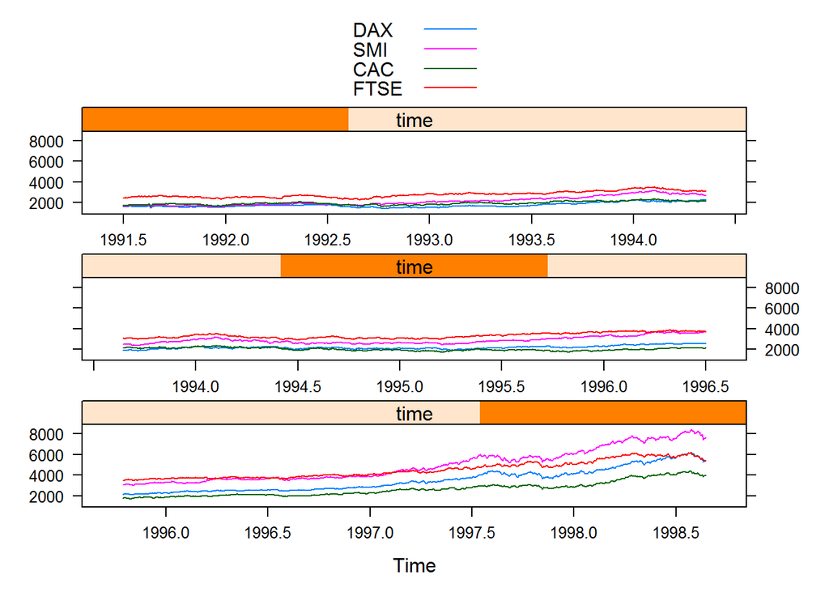

```r
# Create time series plot
xyplot(EuStockMarkets,
       # Plot all series together
       superpose = TRUE,
       # Split up the time axis into parts
       cut = list(number = 3, overlap = 0.25))
```

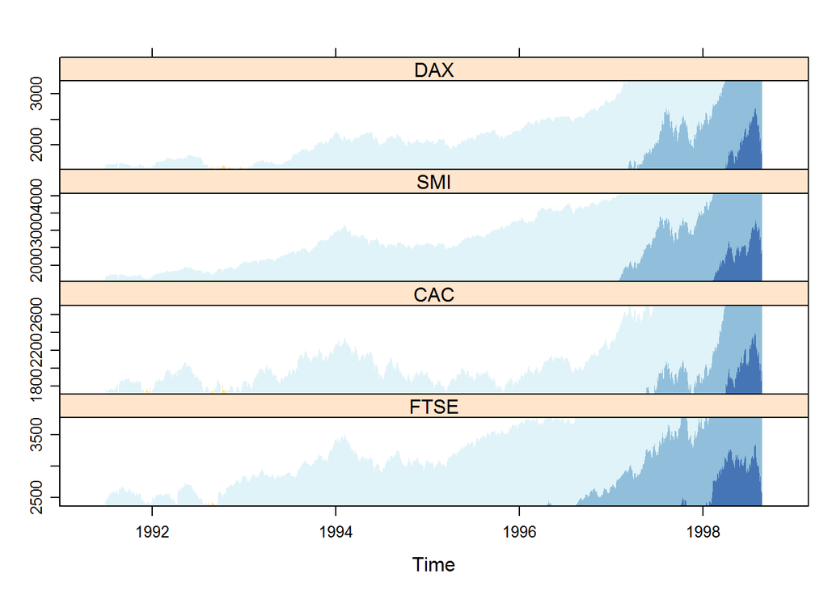

```r
# Create time series plot
xyplot(EuStockMarkets,
       # Specify panel function
       panel=panel.horizonplot,
       # Specify prepanel function
       prepanel=prepanel.horizonplot)
```

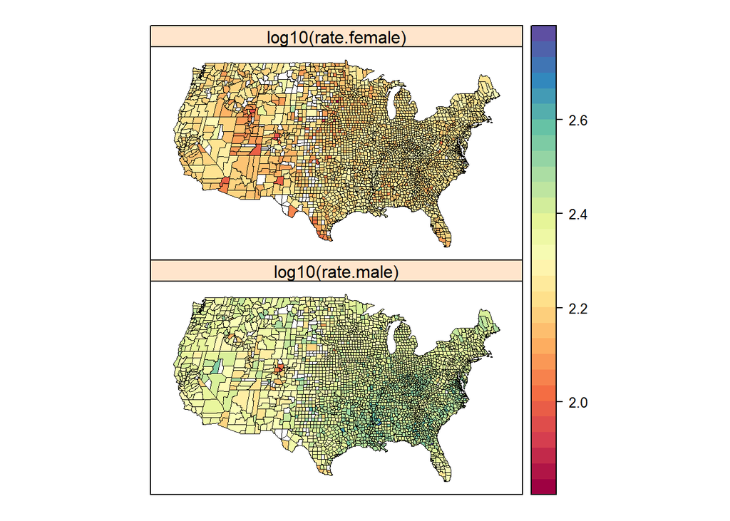

```r
# Load required packages
library(maps)


# Create map object for US counties
county.map <- map("county", plot = FALSE, fill = TRUE,
                  # Specify projection
                  projection = "sinusoidal")

# Create choropleth map
row.names(USCancerRates) <- rn_USCR

mapplot(row.names(USCancerRates) ~ log10(rate.male) + log10(rate.female),
        data = USCancerRates,
        xlab = "", scales = list(draw = FALSE),
        # Specify map
        map = county.map)
```

```r
# Create subset for Louisiana
LACancerRates1 <- filter(USCancerRates, state == "Louisiana")
str(LACancerRates1)
```

```
## 'data.frame':    64 obs. of  11 variables:
##  $ rate.male       : num  369 361 349 338 338 ...
##  $ LCL95.male      : num  316 289 302 308 303 ...
##  $ UCL95.male      : num  428 446 402 372 376 ...
##  $ rate.female     : num  162 193 215 194 192 ...
##  $ LCL95.female    : num  134 150 184 176 170 ...
##  $ UCL95.female    : num  196 246 250 215 218 ...
##  $ state           : Factor w/ 49 levels "Alabama","Alaska",..: 17 17 17 17 17 17 17 17 17 17 ...
##  $ county          :Class 'AsIs'  chr [1:64] "Richland Parish" "Madison Parish" "De Soto Parish" "St. Bernard Parish" ...
##  $ state.ordered   : Factor w/ 49 levels "Utah","New Mexico",..: 46 46 46 46 46 46 46 46 46 46 ...
##   ..- attr(*, "scores")= num [1:49(1d)] 166 166 145 169 159 ...
##   .. ..- attr(*, "dimnames")=List of 1
##   .. .. ..$ : chr  "Alabama" "Alaska" "Arizona" "Arkansas" ...
##  $ division        : Factor w/ 9 levels "New England",..: 5 5 5 5 5 5 5 5 5 5 ...
##  $ division.ordered: Factor w/ 9 levels "Mountain","West North Central",..: 7 7 7 7 7 7 7 7 7 7 ...
##   ..- attr(*, "scores")= num [1:9(1d)] 417 416 446 466 433 ...
##   .. ..- attr(*, "dimnames")=List of 1
##   .. .. ..$ : chr  "New England" "Middle Atlantic" "South Atlantic" "East South Central" ...
```

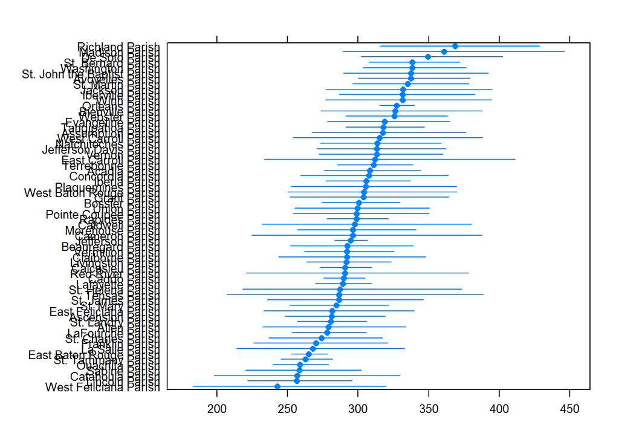

```r
# Reorder levels of county
LACancerRates2 <-
    mutate(LACancerRates1,
           county = reorder(county, rate.male))

# Draw confidence intervals
segplot(county ~ LCL95.male + UCL95.male,
        data = LACancerRates2,
        # Add point estimates
        centers = rate.male,
        # Draw segments rather than bands
        draw.bands = FALSE)
```

```r
# The 'USCancerRates' dataset
str(USCancerRates)
```

```
## 'data.frame':    3041 obs. of  11 variables:
##  $ rate.male       : num  364 346 341 336 330 ...
##  $ LCL95.male      : num  311 274 304 289 293 ...
##  $ UCL95.male      : num  423 431 381 389 371 ...
##  $ rate.female     : num  151 140 182 185 172 ...
##  $ LCL95.female    : num  124 103 161 157 151 ...
##  $ UCL95.female    : num  184 190 206 218 195 ...
##  $ state           : Factor w/ 49 levels "Alabama","Alaska",..: 1 1 1 1 1 1 1 1 1 1 ...
##  $ county          :Class 'AsIs'  chr [1:3041] "Pickens County" "Bullock County" "Russell County" "Barbour County" ...
##  $ state.ordered   : Factor w/ 49 levels "Utah","New Mexico",..: 25 25 25 25 25 25 25 25 25 25 ...
##   ..- attr(*, "scores")= num [1:49(1d)] 166 166 145 169 159 ...
##   .. ..- attr(*, "dimnames")=List of 1
##   .. .. ..$ : chr  "Alabama" "Alaska" "Arizona" "Arkansas" ...
##  $ division        : Factor w/ 9 levels "New England",..: 4 4 4 4 4 4 4 4 4 4 ...
##  $ division.ordered: Factor w/ 9 levels "Mountain","West North Central",..: 9 9 9 9 9 9 9 9 9 9 ...
##   ..- attr(*, "scores")= num [1:9(1d)] 417 416 446 466 433 ...
##   .. ..- attr(*, "dimnames")=List of 1
##   .. .. ..$ : chr  "New England" "Middle Atlantic" "South Atlantic" "East South Central" ...
```

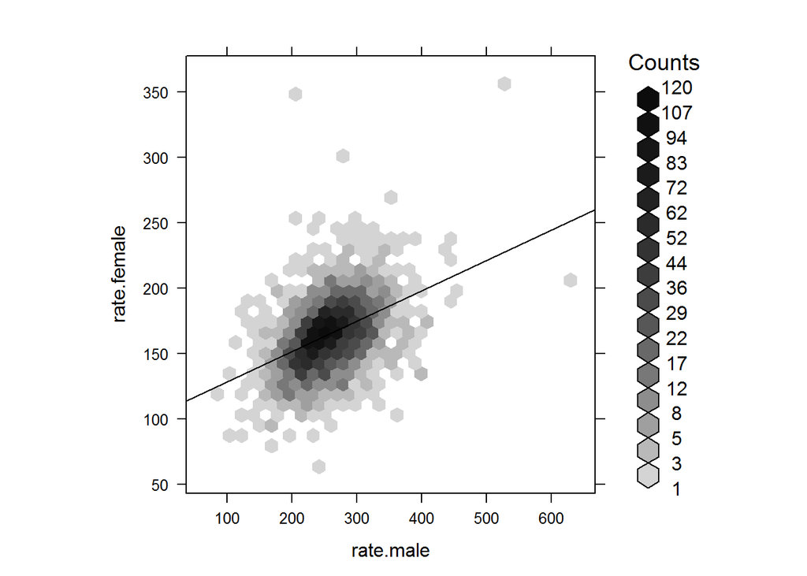

```r
# Load the 'hexbin' package
library(hexbin)

# Create hexbin plot
hexbinplot(rate.female ~ rate.male,
           data = USCancerRates,
           # Add a regression line
           type = "r",
           # function to transform counts
           trans = sqrt,
           # function to invert transformed counts
           inv = function(x) x^2
           )
```

```r
# Load the 'directlabels' package
library(directlabels)

# Use the 'airquality' dataset
str(airquality)
```

```
## 'data.frame':    153 obs. of  7 variables:
##  $ Ozone     : int  41 36 12 18 NA 28 23 19 8 NA ...
##  $ Solar.R   : int  190 118 149 313 NA NA 299 99 19 194 ...
##  $ Wind      : num  7.4 8 12.6 11.5 14.3 14.9 8.6 13.8 20.1 8.6 ...
##  $ Temp      : int  67 72 74 62 56 66 65 59 61 69 ...
##  $ Month     : int  5 5 5 5 5 5 5 5 5 5 ...
##  $ Day       : int  1 2 3 4 5 6 7 8 9 10 ...
##  $ Month.Name: Factor w/ 12 levels "January","February",..: 5 5 5 5 5 5 5 5 5 5 ...
```

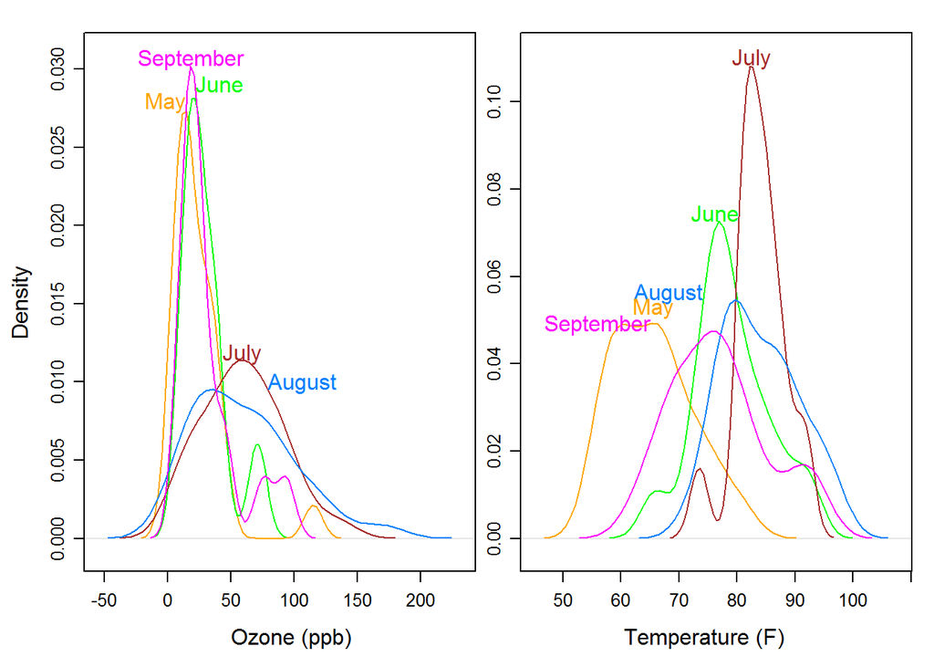

```r
# Create factor variable
airquality$Month.Name <-
    factor(month.name[airquality$Month], levels = month.name)

# Create density plot object
tplot2 <-
    densityplot(~ Ozone + Temp, data = airquality,
                # Variables should go in different panels
                outer = TRUE,
                # Specify grouping variable
                groups = Month.Name,
                # Suppress display of data points
                plot.points = FALSE,
                # Add reference line
                ref = TRUE,
                # Specify layout
                layout = c(2, 1),
                # Omit strip labels
                strip = FALSE,
                # Provide column-specific x-axis labels
                xlab = c("Ozone (ppb)", "Temperature (F)"),
                # Let panels have independent scales
                scales = list(relation="free"))

# Produce plot with direct labels
direct.label(tplot2)
```

```r
# 'USCancerRates' is pre-loaded
str(USCancerRates)
```

```
## 'data.frame':    3041 obs. of  11 variables:
##  $ rate.male       : num  364 346 341 336 330 ...
##  $ LCL95.male      : num  311 274 304 289 293 ...
##  $ UCL95.male      : num  423 431 381 389 371 ...
##  $ rate.female     : num  151 140 182 185 172 ...
##  $ LCL95.female    : num  124 103 161 157 151 ...
##  $ UCL95.female    : num  184 190 206 218 195 ...
##  $ state           : Factor w/ 49 levels "Alabama","Alaska",..: 1 1 1 1 1 1 1 1 1 1 ...
##  $ county          :Class 'AsIs'  chr [1:3041] "Pickens County" "Bullock County" "Russell County" "Barbour County" ...
##  $ state.ordered   : Factor w/ 49 levels "Utah","New Mexico",..: 25 25 25 25 25 25 25 25 25 25 ...
##   ..- attr(*, "scores")= num [1:49(1d)] 166 166 145 169 159 ...
##   .. ..- attr(*, "dimnames")=List of 1
##   .. .. ..$ : chr  "Alabama" "Alaska" "Arizona" "Arkansas" ...
##  $ division        : Factor w/ 9 levels "New England",..: 4 4 4 4 4 4 4 4 4 4 ...
##  $ division.ordered: Factor w/ 9 levels "Mountain","West North Central",..: 9 9 9 9 9 9 9 9 9 9 ...
##   ..- attr(*, "scores")= num [1:9(1d)] 417 416 446 466 433 ...
##   .. ..- attr(*, "dimnames")=List of 1
##   .. .. ..$ : chr  "New England" "Middle Atlantic" "South Atlantic" "East South Central" ...
```

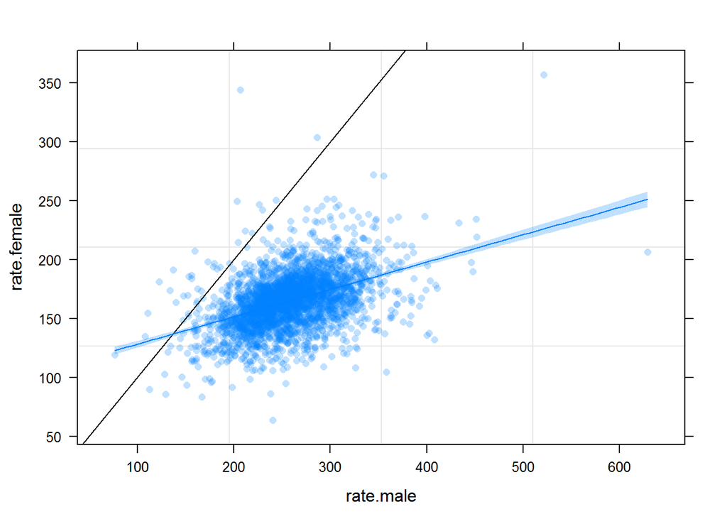

```r
# Create scatter plot
p <- xyplot(rate.female ~ rate.male, data = USCancerRates,
            # Change plotting character
            pch = 16,
            # Make points semi-transparent
            alpha = 0.25)

# Create layer with reference grid
l0 <- layer_(panel.grid())

# Create layer with reference line
l1 <- layer(panel.abline(0, 1))

# Create layer with regression fit
l2 <- layer(panel.smoother(x, y, method="lm"))

# Combine and plot
p + l0 + l1 + l2
```

### *Visualizing Time Series Data in R*

Chapter 1 - R Time Series Visualization Tools

Refresher on xts and the plot() function:

- With a time series plot, each element is associated to a specific time
- The xts objects is typically the storage mechanism for times series data in R
  - Time Index (Date, POSIXct, or the like) + Matrix
- The plot() call can be used on xts objects and will call plot.xts() to achieve this purpose
  - Many of the calls are similar to a normal plot() - for example, can overwrite using lines()

Other useful visualizing functions:

- Can use lines() to add a line to an existing time series plot
- Can use axis(side=, at=) # 1 bottom, 2 left, 3 top, 4 right ; can use at=pretty(existingPlotData)
- Can add legends using legend(x=, legend=, col=, lty=)
- Can add lines to a plot using abline(v=, h=)
- The PerformanceAnalytics package allows for better highlighting portions of the plot
- To highlight a specific period in a time series, you can display it in the plot in a different background color
  - The chart.TimeSeries() function in the PerformanceAnalytics package offers a very easy and flexible way of doing this
  - chart.TimeSeries(R, period.areas, period.color)
  - R is an xts, time series, or zoo object of asset returns
  - period.areas are shaded areas specified by a start and end date in a vector of xts date ranges like c(“1926-10/1927-11”)
  - period.color draws the shaded region in whichever color is specified

Example code includes:

```r
library(xts)
# data is a 504x4 xts object of Yahoo, Microsoft, Citigroup, and Dow
tmpData <- readr::read_delim("./RInputFiles/dataset_1_1.csv", delim=" ")
data <- xts::xts(tmpData[, -1], order.by=as.POSIXct(tmpData$Index))


# Display the first few lines of the data
head(data)
```

```
##                     yahoo microsoft citigroup dow_chemical
## 2015-01-01 18:00:00 50.17  44.30501  53.45259     42.48209
## 2015-01-04 18:00:00 49.13  43.89759  51.76803     41.16821
## 2015-01-05 18:00:00 49.21  43.25329  49.94556     40.50662
## 2015-01-06 18:00:00 48.59  43.80284  50.40857     40.44139
## 2015-01-07 18:00:00 50.23  45.09144  51.16711     41.44776
## 2015-01-08 18:00:00 49.72  44.71244  50.02437     41.38253
```

```r
# Display the column names of the data
colnames(data)
```

```
## [1] "yahoo"        "microsoft"    "citigroup"    "dow_chemical"
```

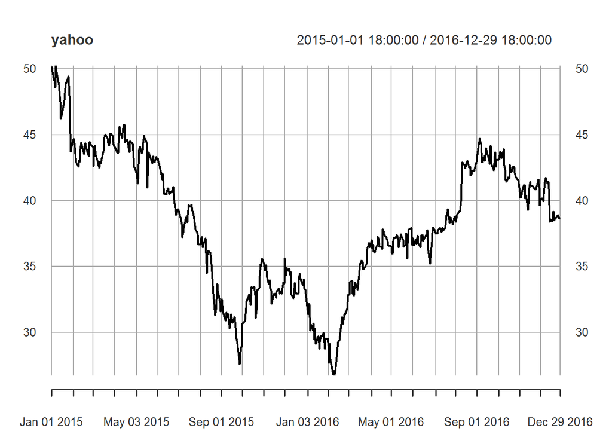

```r
# Plot yahoo data and add title
plot(data[, "yahoo"], main="yahoo")

# Replot yahoo data with labels for X and Y axes
plot(data[, "yahoo"], main="yahoo", xlab="date", ylab="price")
```

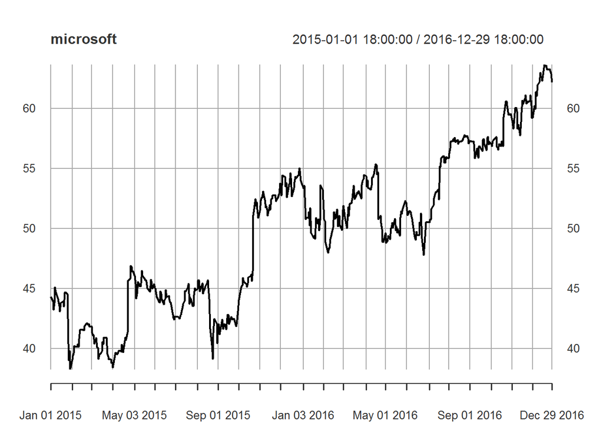

```r
# Note that type="h" is for bars
# Plot the second time series and change title
plot(data[, 2], main="microsoft")
```

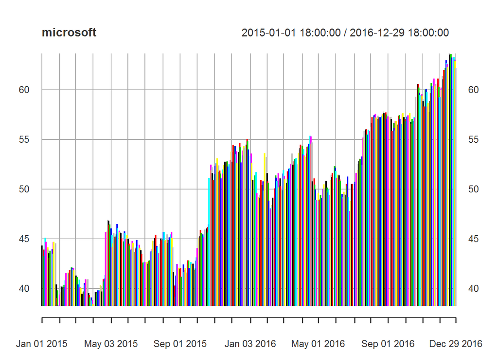

```r
# Replot with same title, add subtitle, use bars
plot(data[, 2], main="microsoft", sub="Daily closing price since 2015", type="h")
```

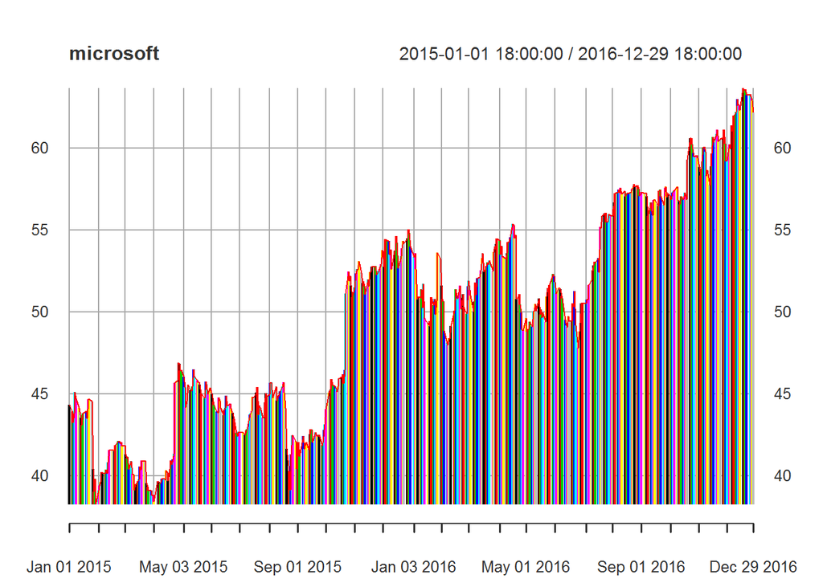

```r
# Change line color to red
lines(data[, 2], col="red")
```

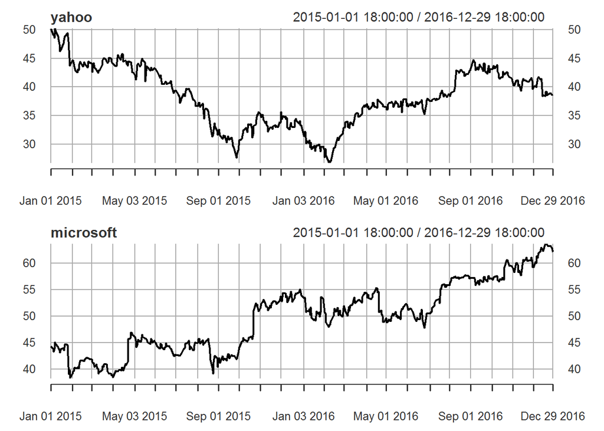

```r
# Plot two charts on same graphical window
par(mfrow = c(2, 1))
plot(data[, 1], main="yahoo")
plot(data[, 2], main="microsoft")
```

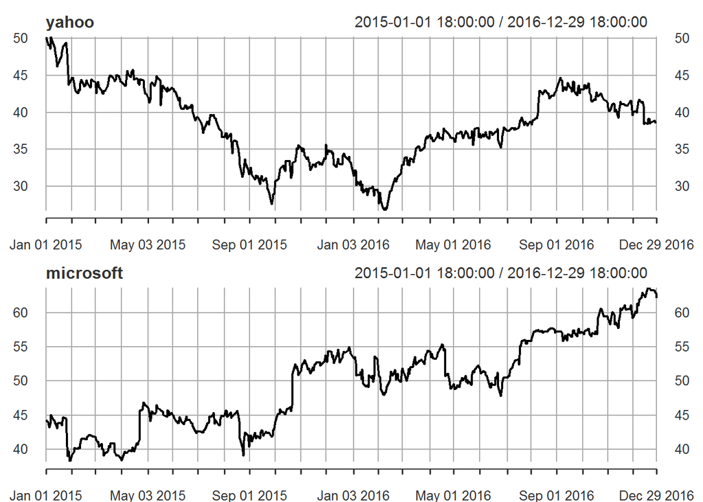

```r
# Replot with reduced margin and character sizes
par(mfrow = c(2, 1), mex=0.6, cex=0.8)
plot(data[, 1], main="yahoo")
plot(data[, 2], main="microsoft")
```

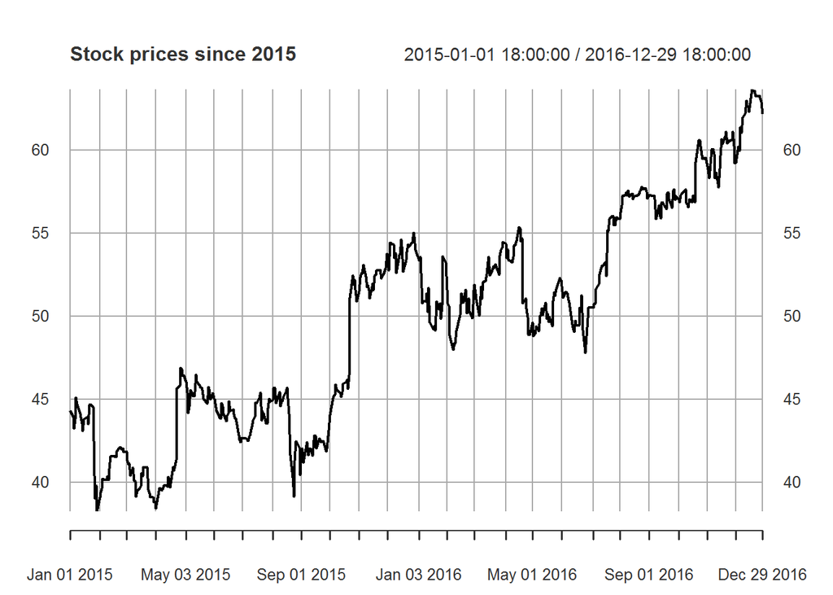

```r
par(mfrow = c(1, 1), mex=1, cex=1)


# Plot the "microsoft" series
plot(data[, "microsoft"], main="Stock prices since 2015")
```

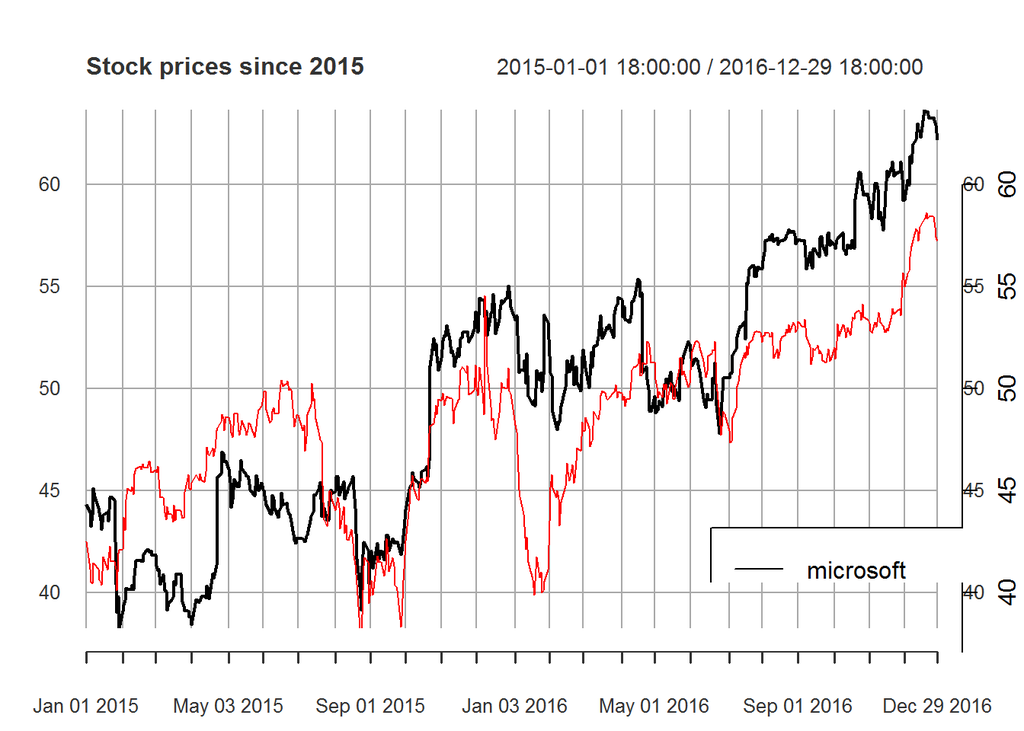

```r
# Add the "dow_chemical" series in red
lines(data[, "dow_chemical"], col="red")

# Add a Y axis on the right side of the chart
axis(side=4, at=pretty(data[, "dow_chemical"]))

# Add a legend in the bottom right corner
legend("bottomright", legend=c("microsoft", "dow_chemical"), col=c("black", "red"), lty=c(1, 1))
```

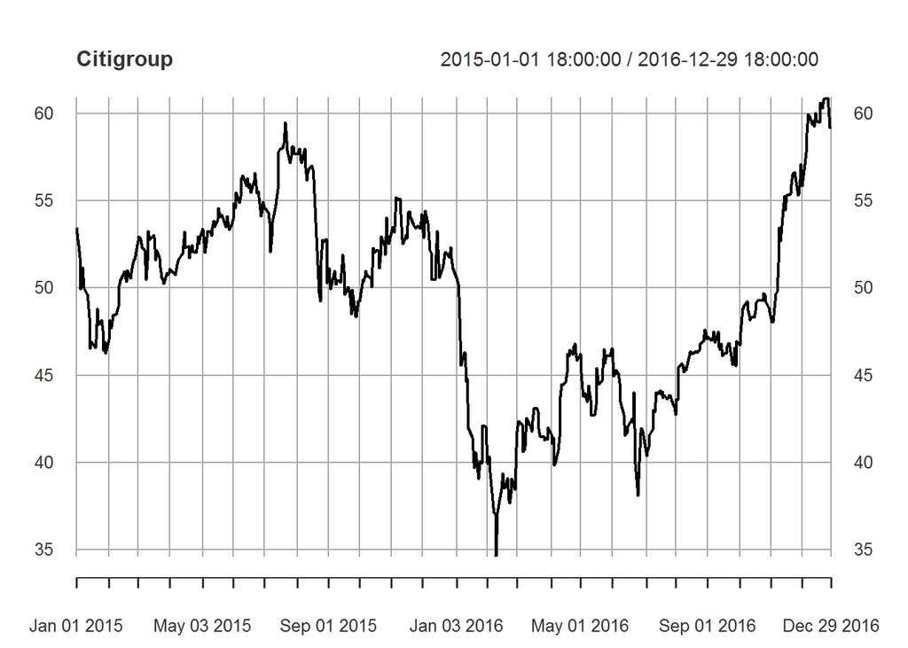

```r
# Plot the "citigroup" time series
plot(data[, "citigroup"], main="Citigroup")

# Create vert_line to identify January 4th, 2016 in citigroup
vert_line <- which(index(data[, "citigroup"]) == as.POSIXct("2016-01-04"))

# Add a red vertical line using vert_line
abline(v = .index(data[, "citigroup"])[vert_line], col = "red")

# Create hori_line to identify average price of citigroup
hori_line <- mean(data[, "citigroup"])

# Add a blue horizontal line using hori_line
abline(h = hori_line, col = "blue")
```

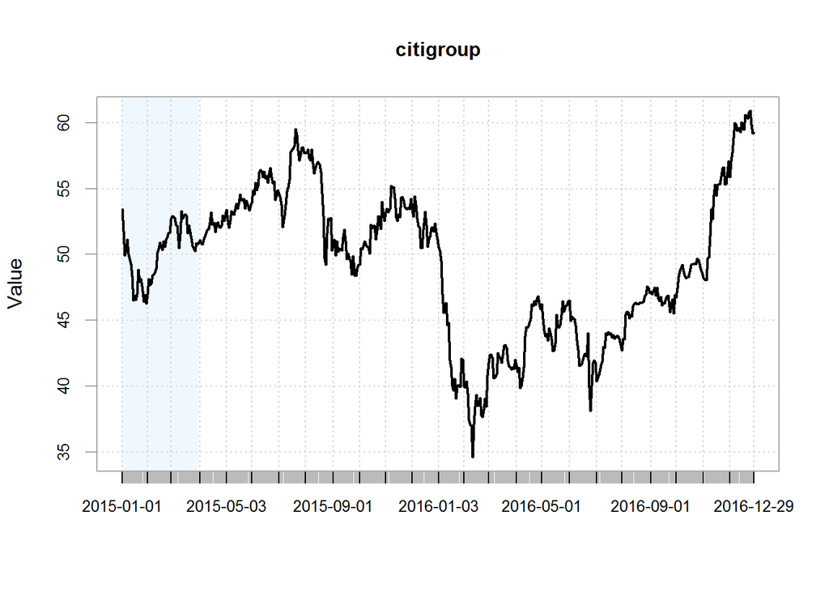

```r
# Create period to hold the 3 months of 2015
period <- c("2015-01/2015-03")

# Highlight the first three months of 2015
PerformanceAnalytics::chart.TimeSeries(data[, "citigroup"], period.areas=period)
```

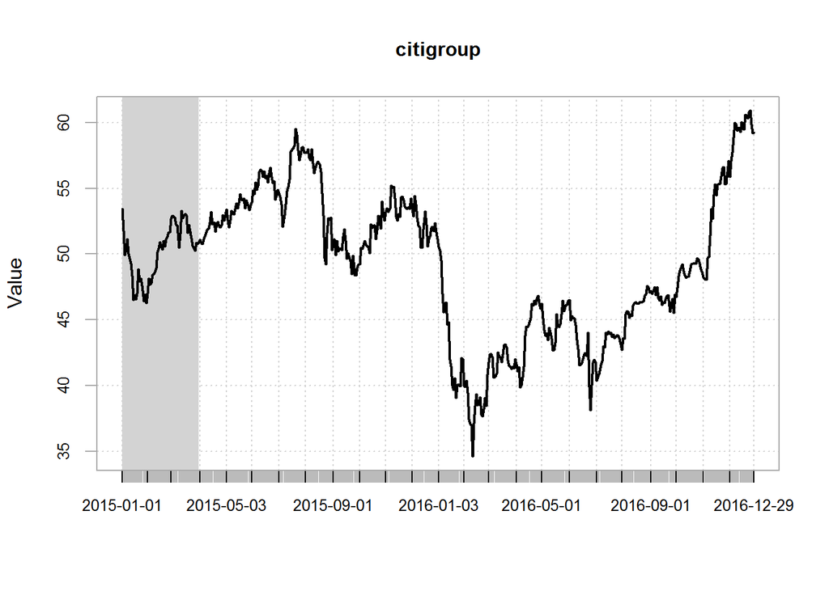

```r
# Highlight the first three months of 2015 in light grey
PerformanceAnalytics::chart.TimeSeries(data[, "citigroup"], period.areas=period, period.color="lightgrey")
```

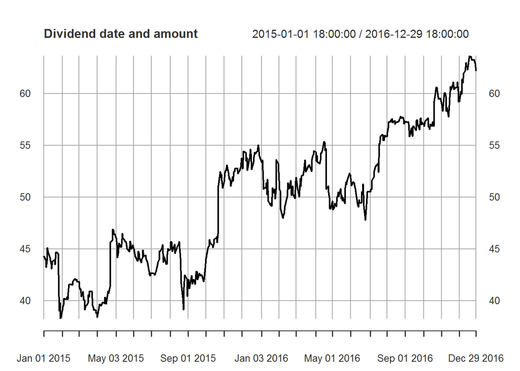

```r
# Plot the microsoft series
plot(data[, "microsoft"], main="Dividend date and amount")
```

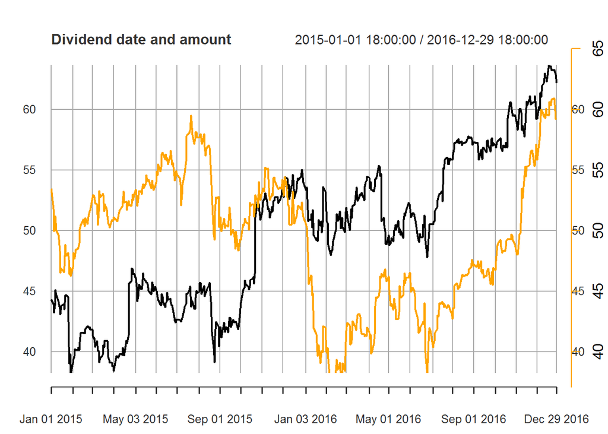

```r
# Add the citigroup series
lines(data[, "citigroup"], col="orange", lwd=2)

# Add a new y axis for the citigroup series
axis(side=4, at=pretty(data[, "citigroup"]), col="orange")
```

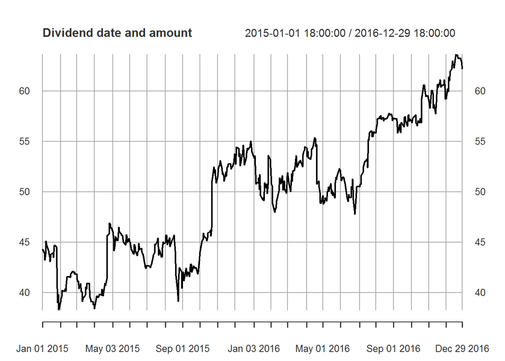

```r
micro_div_date <- "15 Nov. 2016"
citi_div_date <- "13 Nov. 2016"
micro_div_value <- "$0.39"
citi_div_value <- "$0.16"
# Same plot as the previous exercise
plot(data$microsoft, main = "Dividend date and amount")
```

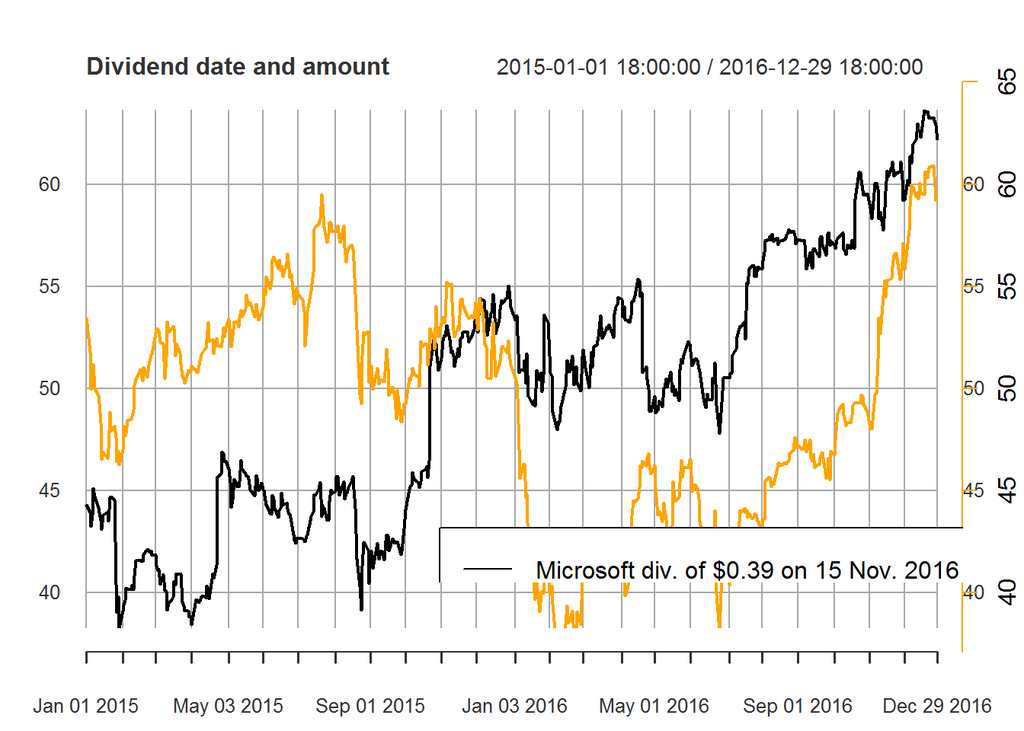

```r
lines(data$citigroup, col = "orange", lwd = 2)
axis(side = 4, at = pretty(data$citigroup), col = "orange")

# Create the two legend strings
micro <- paste0("Microsoft div. of ", micro_div_value," on ", micro_div_date)
citi <- paste0("Citigroup div. of ", citi_div_value," on ", citi_div_date)

# Create the legend in the bottom right corner
legend(x = "bottomright", legend = c(micro, citi), col = c("black", "orange"), lty = c(1, 1))
```

```r
data_1_1_old <- data
```

Chapter 2 - Univariate Time Series

Univariate time series analysis - deals with only a single variable:

- Location, Dispersion, Distribution - frequently presented by way of histograms
- Time series typically need to be transformed prior to these calculations, since their data is in the wrong format otherwise
  - For example, it is often more helpful to get the distribution of price change (and/or percentage return) rather than just the stock price
- In finance, price series are often transformed to differenced data, making it a return series
  - In R, the ROC() (which stands for “Rate of Change”) function from the TTR package does this automatically to a price or volume series x

Other visualization tools:

- Can create histograms of stock returns
- Can use boxplot() to see the box-and-whisker of the stock returns
  - The argument horizontal=TRUE will display the block horizontally
- Can run acf() to see the autocorrelation of the returns
- Can run qqnorm() and qqline() to see whether the data are normally distributed

Combining everything so far:

- The histogram helps with understanding both central tendencies and outliers
  - The box and whiskers plot helps in a similar manner - also helps to show investment riskiness
- The autocorrelation plot helps with understanding the linkages between today and days in the future
- The QQ plot helps to assess whether methods/tests that rely on normality can be safely used on the dataset

Example code includes:

```r
tmpData <- readr::read_delim("./RInputFiles/dataset_2_1.csv", delim=" ")
```

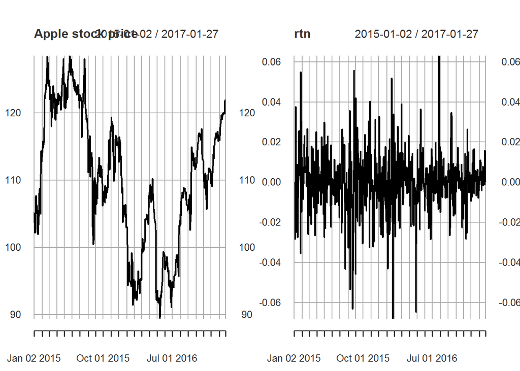

```r
names(tmpData) <- c("Index", "apple")
data <- xts::xts(tmpData[, -1], order.by=as.Date(tmpData$Index))
# indexClass(data) <- c("POSIXt", "POSIXlt")

# Plot Apple's stock price
plot(data[, "apple"], main="Apple stock price")

# Create a time series called rtn
rtn <- TTR::ROC(data[, "apple"])

# Plot Apple daily price and daily returns
par(mfrow=c(1, 2))
plot(data[, "apple"], main="Apple stock price")
plot(rtn)
```

```r
par(mfrow=c(1, 1))


dim(rtn)
```

```
## [1] 522   1
```

```r
rtn <- rtn[complete.cases(rtn), ]
dim(rtn)
```

```
## [1] 521   1
```

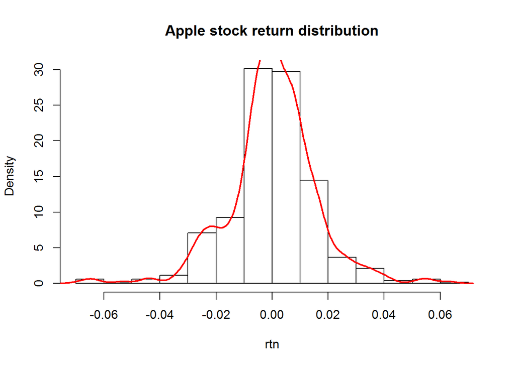

```r
# Create a histogram of Apple stock returns
hist(rtn, main="Apple stock return distribution", probability=TRUE)

# Add a density line
lines(density(rtn[complete.cases(rtn), ]))

# Redraw a thicker, red density line
lines(density(rtn[complete.cases(rtn), ]), col="red", lwd=2)
```

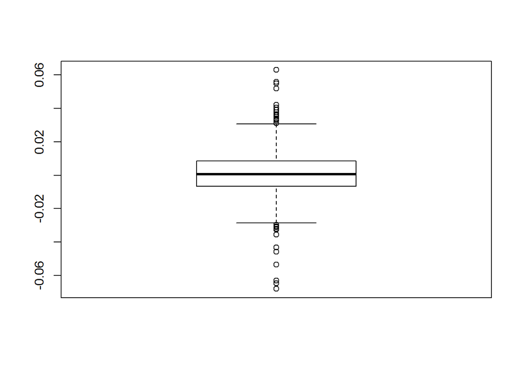

```r
rtnRaw <- as.double(rtn$apple)

# Draw box and whisker plot for the Apple returns
boxplot(rtnRaw)
```

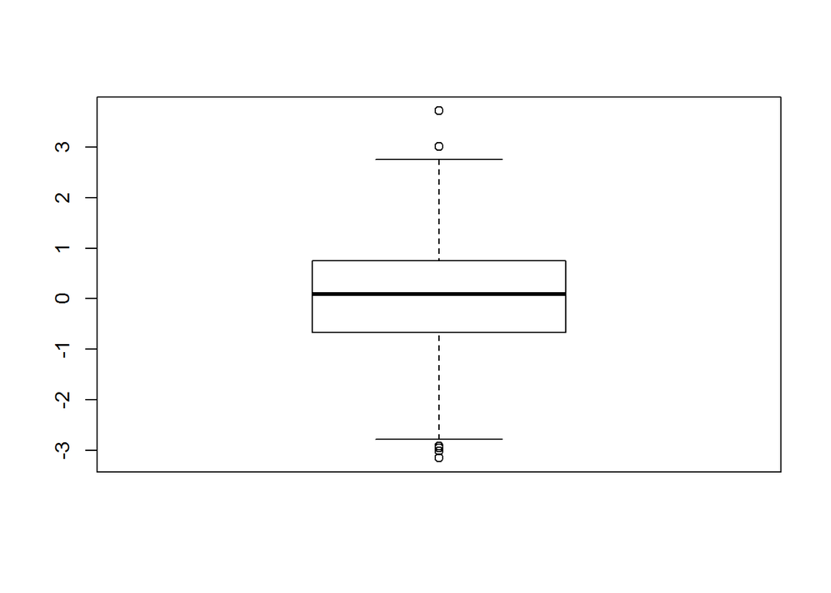

```r
# Draw a box and whisker plot of a normal distribution
boxplot(rnorm(1000))
```

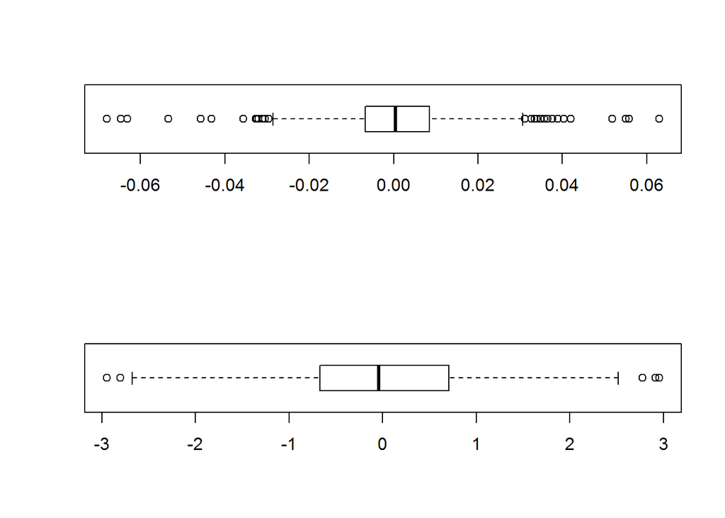

```r
# Redraw both plots on the same graphical window
par(mfrow=c(2, 1))
boxplot(rtnRaw, horizontal=TRUE)
boxplot(rnorm(1000), horizontal=TRUE)
```

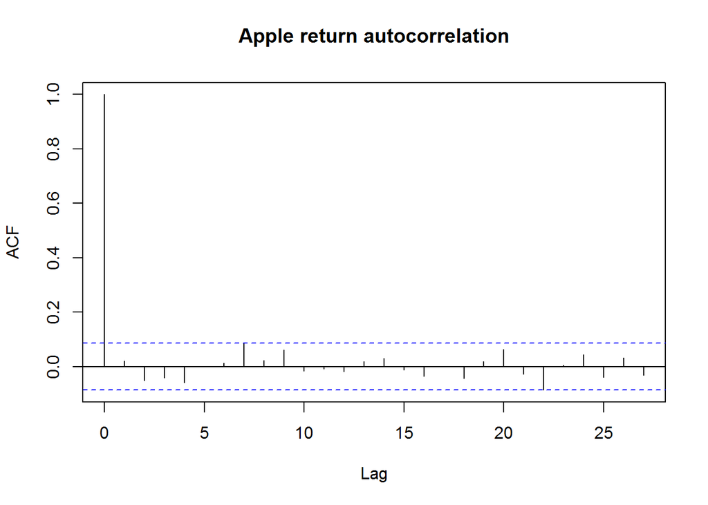

```r
par(mfrow=c(1, 1))


# Draw autocorrelation plot
acf(rtn, main="Apple return autocorrelation")
```

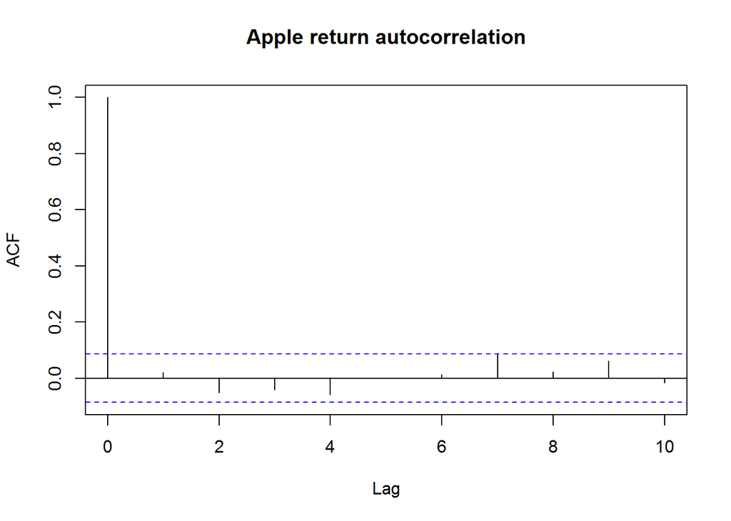

```r
# Redraw with a maximum lag of 10
acf(rtn, main="Apple return autocorrelation", lag.max=10)
```

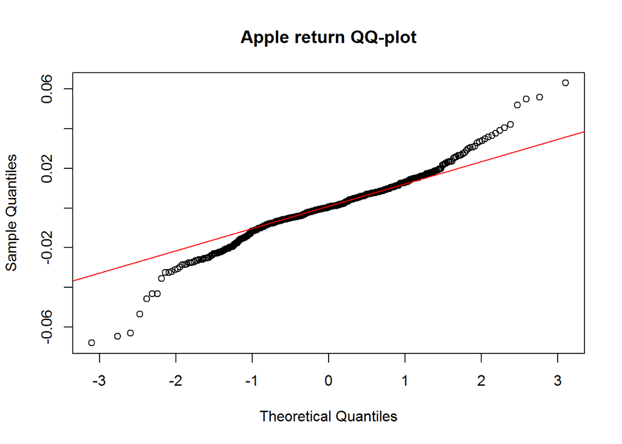

```r
# Create q-q plot
qqnorm(rtn, main="Apple return QQ-plot")

# Add a red line showing normality
qqline(rtn, col="red")
```

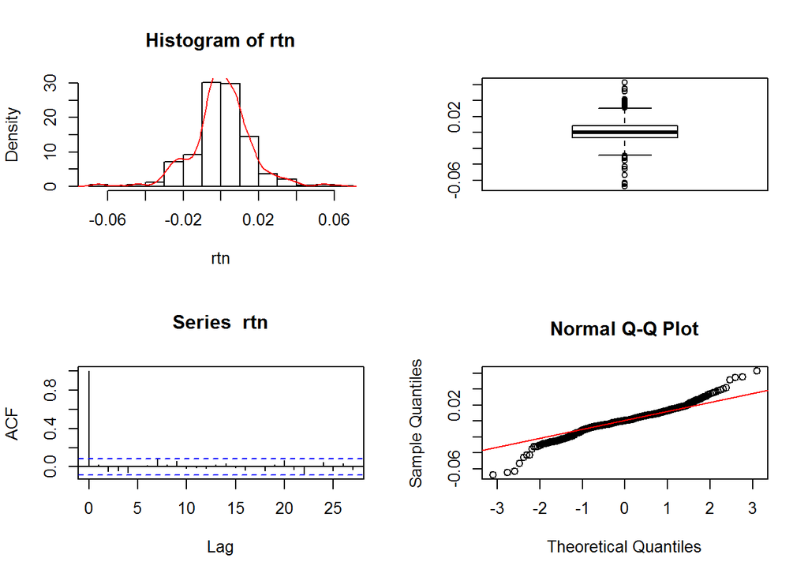

```r
par(mfrow=c(2, 2))

hist(rtn, probability=TRUE)
lines(density(rtn), col="red")
boxplot(rtnRaw)
acf(rtn)
qqnorm(rtn)
qqline(rtn, col="red")
```

```r
par(mfrow=c(1, 1))
```

Chapter 3 - Multivariate Time Series

Dealing with higher dimensions - visualization challenges with larger numbers of series:

- Might want to compare stock prices vs interest rate changes
- Cannot easily visualize even 10 time series, let alone 100 time series
- One solution is to plot both time series as barcharts. There are two types:
  - Grouped barchart: for a single period, there are as many bars as time series
  - Stacked bar chart: for each period, there is a single bar, and each time series is represented by a portion of the bar proportional to the value of the time series at this date (i.e. the total at each period adds up to 100%)

Multivariate time series:

- To create a stacked chart, use barchart(myFrame, col=c(), main=) # can specify the desired colors in the barchart or use the defaults
- Can create the correlation matrix using cor(myMatrix, digit=)
  - Several types of correlations exist but the most used ones are:
  - Pearson correlation: measures the linear relationship between 2 variables
  - Spearman rank correlation: measures the statistical dependency between the ranking of 2 variables (not necessarily linear)
- Can create the pair chart using pairs(myFrame, lower.panel=NULL, main=) # the lower.panel=NULL shows only the diagonal and the upper-right of the pairs plot
- Can create a correlation plot using corrplot(myMatrix, method=“number”, type=“upper”) # type=“upper” shows only the upper-right of the diagonal

Higher dimension time series:

- Can display a correlation matrix as a heat map
  - corrplot(myMatrix, method=“color”, type=“upper”)

Example code includes:

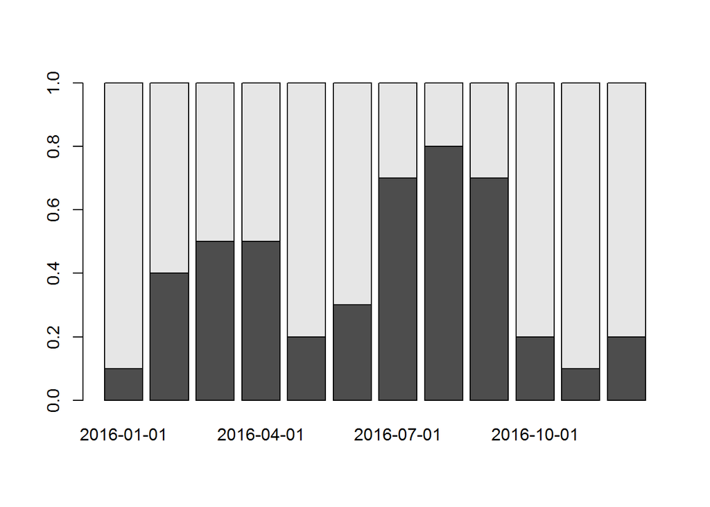

```r
# You are provided with a dataset (portfolio) containing the weigths of stocks A (stocka) and B (stockb) in your portfolio for each month in 2016
stockA <- c(0.1, 0.4, 0.5, 0.5, 0.2, 0.3, 0.7, 0.8, 0.7, 0.2, 0.1, 0.2)
stockB <- c(0.9, 0.6, 0.5, 0.5, 0.8, 0.7, 0.3, 0.2, 0.3, 0.8, 0.9, 0.8)
pDates <- as.Date(c('2016-01-01', '2016-02-01', '2016-03-01', '2016-04-01', '2016-05-01', '2016-06-01', '2016-07-01', '2016-08-01', '2016-09-01', '2016-10-01', '2016-11-01', '2016-12-01'))
portfolio <- xts(data.frame(stocka=stockA, stockb=stockB), order.by=pDates)

# Plot stacked barplot
barplot(portfolio)
```

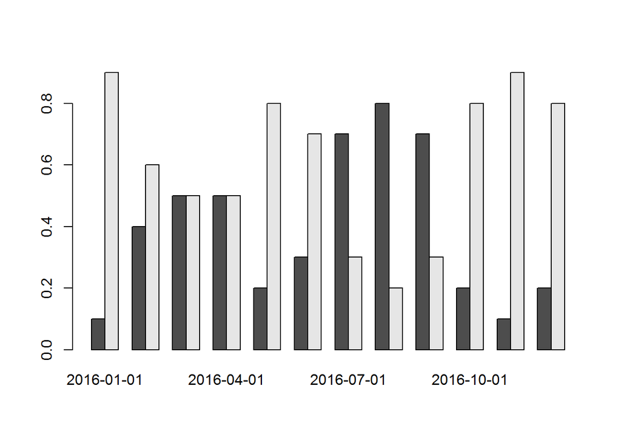

```r
# Plot grouped barplot
barplot(portfolio, beside=TRUE)
```

```r
tmpData <- readr::read_delim("./RInputFiles/data_3_2.csv", delim=",")
```

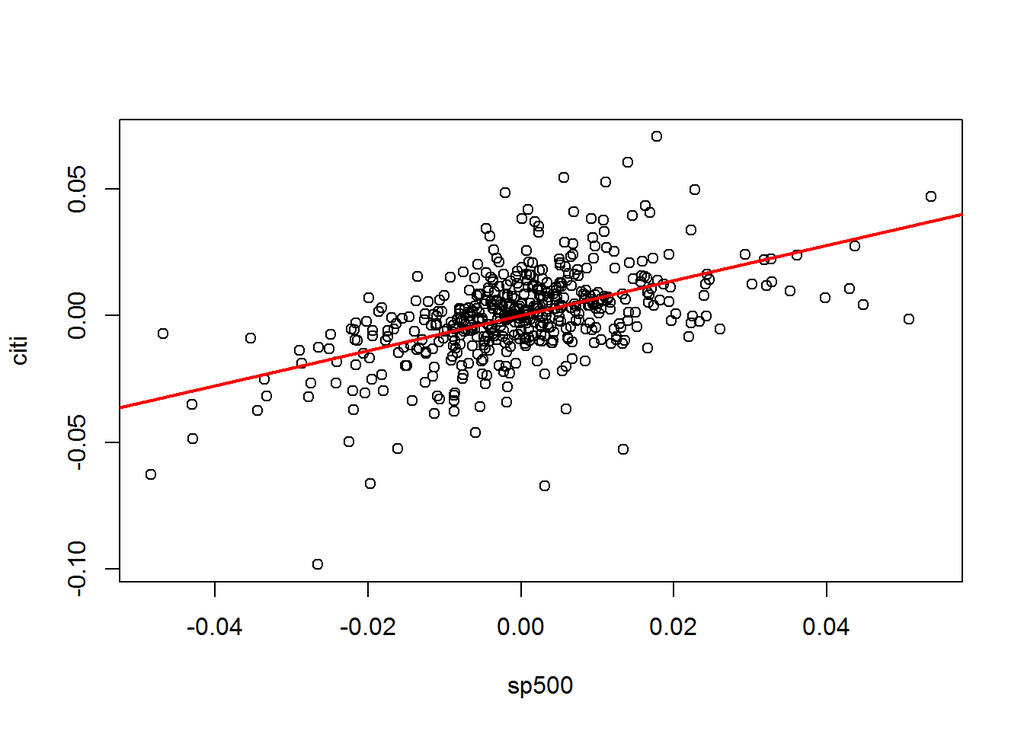

```r
# names(tmpData) <- c("Index", "apple")
my_data <- xts::xts(tmpData[, -1], order.by=as.Date(tmpData$Index))


citi <- as.numeric(my_data$citigroup)
sp500 <- as.numeric(my_data$sp500)

# Draw the scatterplot
plot(y=citi, x=sp500)

# Draw a regression line
abline(reg=lm(citi ~ sp500), col="red", lwd=2)
```